# Predicting Loan Status

The goal of this project is to make a model which will predict a customer's loan status given a number of attributes such as the current loan amount and whether the loan is a long term loan or a short term loan.

Import packages

```python
import pandas as pd
import matplotlib.pyplot as plt
import seaborn as sns
df = pd.read_csv('LoansTrainingSet.csv')
df.head()
```

|  | Loan ID | Customer ID | Loan Status | Current Loan Amount | Term | Credit Score | Years in current job | Home Ownership | Annual Income | Purpose | Monthly Debt | Years of Credit History | Months since last delinquent | Number of Open Accounts | Number of Credit Problems | Current Credit Balance | Maximum Open Credit | Bankruptcies | Tax Liens |
| --- | --- | --- | --- | --- | --- | --- | --- | --- | --- | --- | --- | --- | --- | --- | --- | --- | --- | --- | --- |
| 0 | 000025bb-5694-4cff-b17d-192b1a98ba44 | 5ebc8bb1-5eb9-4404-b11b-a6eebc401a19 | Fully Paid | 11520 | Short Term | 741.0 | 10+ years | Home Mortgage | 33694.0 | Debt Consolidation | $584.03 | 12.3 | 41.0 | 10 | 0 | 6760 | 16056 | 0.0 | 0.0 |
| 1 | 00002c49-3a29-4bd4-8f67-c8f8fbc1048c | 927b388d-2e01-423f-a8dc-f7e42d668f46 | Fully Paid | 3441 | Short Term | 734.0 | 4 years | Home Mortgage | 42269.0 | other | $1,106.04 | 26.3 | NaN | 17 | 0 | 6262 | 19149 | 0.0 | 0.0 |
| 2 | 00002d89-27f3-409b-aa76-90834f359a65 | defce609-c631-447d-aad6-1270615e89c4 | Fully Paid | 21029 | Short Term | 747.0 | 10+ years | Home Mortgage | 90126.0 | Debt Consolidation | $1,321.85 | 28.8 | NaN | 5 | 0 | 20967 | 28335 | 0.0 | 0.0 |
| 3 | 00005222-b4d8-45a4-ad8c-186057e24233 | 070bcecb-aae7-4485-a26a-e0403e7bb6c5 | Fully Paid | 18743 | Short Term | 747.0 | 10+ years | Own Home | 38072.0 | Debt Consolidation | $751.92 | 26.2 | NaN | 9 | 0 | 22529 | 43915 | 0.0 | 0.0 |
| 4 | 0000757f-a121-41ed-b17b-162e76647c1f | dde79588-12f0-4811-bab0-e2b07f633fcd | Fully Paid | 11731 | Short Term | 746.0 | 4 years | Rent | 50025.0 | Debt Consolidation | $355.18 | 11.5 | NaN | 12 | 0 | 17391 | 37081 | 0.0 | 0.0 |

Check for duplicated rows

```python
df[df.duplicated()==True]
```

|  | Loan ID | Customer ID | Loan Status | Current Loan Amount | Term | Credit Score | Years in current job | Home Ownership | Annual Income | Purpose | Monthly Debt | Years of Credit History | Months since last delinquent | Number of Open Accounts | Number of Credit Problems | Current Credit Balance | Maximum Open Credit | Bankruptcies | Tax Liens |
| --- | --- | --- | --- | --- | --- | --- | --- | --- | --- | --- | --- | --- | --- | --- | --- | --- | --- | --- | --- |
| 14 | 00029f9f-0cc5-4d4e-aabc-ea4a7fe74e12 | afbc2fa3-3bad-4d48-b691-829aed78bad5 | Charged Off | 17961 | Short Term | 701.0 | < 1 year | Own Home | 53053.0 | Debt Consolidation | $596.85 | 9.9 | 43.0 | 7 | 0 | 6810 | 22775 | 0.0 | 0.0 |
| 19 | 00035328-2636-4390-8322-5841de482d2b | 28eb75ac-6a09-4057-b73f-726c72ebf933 | Charged Off | 11604 | Short Term | 729.0 | 6 years | Home Mortgage | 35315.0 | Debt Consolidation | $662.16 | 15.0 | NaN | 12 | 0 | 17092 | 20743 | 0.0 | 0.0 |
| 32 | 0006572c-9567-484d-b49b-bfe06536aa96 | c1a7ba66-9f36-4f5c-86cd-1aa7ad68b954 | Charged Off | 14727 | Short Term | 740.0 | 3 years | Home Mortgage | 70690.0 | Debt Consolidation | $1,083.91 | 18.0 | 27.0 | 12 | 0 | 43375 | 225911 | 0.0 | 0.0 |
| 37 | 000795b0-d767-42bf-837a-80d5b78c1e50 | b533c78c-3096-4914-acb1-5453c0ff76a4 | Charged Off | 19731 | Long Term | 623.0 | 3 years | Rent | 43846.0 | Buy House | $738.08 | 16.2 | 55.0 | 13 | 1 | 9031 | 17955 | 1.0 | 0.0 |
| 40 | 0008a65c-3054-4b5d-931d-8352021f813d | 04513d99-d809-4eb6-b4bb-6abc767d861e | Charged Off | 7066 | Short Term | 741.0 | 10+ years | Own Home | 60564.0 | Debt Consolidation | $706.58 | 14.6 | 56.0 | 4 | 0 | 6229 | 9242 | 0.0 | 0.0 |
| 106 | 001b2e80-1220-40f4-87ad-63fc4814bdfe | f7d50460-c0a5-45d0-ae25-891947b4c7b9 | Charged Off | 11316 | Long Term | 703.0 | 6 years | Rent | 80832.0 | Debt Consolidation | $714.02 | 17.8 | 71.0 | 5 | 1 | 3666 | 7376 | 1.0 | 0.0 |
| 118 | 001df440-3495-4ea7-b519-b7b85dd7ad0e | c550dd85-dccb-4441-b2fe-a06e90bf48de | Charged Off | 22059 | Long Term | 679.0 | 10+ years | Home Mortgage | 200540.0 | Debt Consolidation | $578.23 | 24.1 | 38.0 | 10 | 0 | 17642 | 41904 | 0.0 | 0.0 |
| 131 | 0021a33d-62ce-44fa-9c8f-7b5396a1be81 | 9681f4f0-4d57-48e2-917d-a5f6d3accaab | Charged Off | 11945 | Short Term | NaN | 5 years | Rent | NaN | Debt Consolidation | $675.21 | 18.6 | NaN | 8 | 0 | 5258 | 22278 | 0.0 | 0.0 |
| 157 | 0027a983-b2d4-4363-8191-2e5480a92549 | 0c8991e7-43fe-478b-94cc-ba1185f3eb05 | Charged Off | 10057 | Short Term | NaN | 3 years | Rent | NaN | Debt Consolidation | $1,089.87 | 16.4 | 15.0 | 11 | 0 | 11615 | 14234 | 0.0 | 0.0 |
| 167 | 002a0be9-3c47-4471-bfac-130d33cdb038 | e6dad351-ac76-4453-827a-7841ceaf0914 | Charged Off | 19173 | Short Term | 609.0 | < 1 year | Home Mortgage | 80728.0 | Other | $905.50 | 19.6 | 14.0 | 5 | 0 | 12594 | 12619 | 0.0 | 0.0 |
| 182 | 002d9230-a4a2-4a53-b2e6-95df00866341 | a96d08d2-cbb3-42d8-9718-909f1ccfc9ad | Charged Off | 9795 | Short Term | 687.0 | 6 years | Rent | 27496.0 | other | $788.22 | 6.6 | 40.0 | 4 | 0 | 2290 | 4626 | 0.0 | 0.0 |
| 201 | 00336793-40a5-448c-81a6-528bf04a04ba | 7b182b4a-d3ed-419a-b889-83f44fff2203 | Charged Off | 7886 | Short Term | 741.0 | 5 years | Rent | 23854.0 | Debt Consolidation | $415.45 | 6.2 | NaN | 6 | 0 | 5394 | 6801 | 0.0 | 0.0 |
| 207 | 0033eb55-3702-4a17-8e68-ef95f3f57053 | 58a5de0c-b628-4730-a25f-5239ab65e191 | Charged Off | 2297 | Short Term | 708.0 | 5 years | Rent | 27564.0 | Debt Consolidation | $243.48 | 6.9 | NaN | 10 | 0 | 3859 | 12449 | 0.0 | 0.0 |
| 221 | 00393195-42fd-4b0f-a019-10cb0c86dce4 | 3fc2799b-87d2-4068-b4d9-abfba07be5be | Charged Off | 15958 | Short Term | 713.0 | 10+ years | Own Home | 48800.0 | Debt Consolidation | $727.93 | 17.0 | NaN | 9 | 1 | 11523 | 18146 | 0.0 | 0.0 |
| 228 | 003a346b-6ede-4179-8991-c63c4ef9af55 | ecad702f-d39e-46c9-9418-ac291588bc2d | Charged Off | 15018 | Long Term | 732.0 | 9 years | Home Mortgage | 45054.0 | Debt Consolidation | $1,006.21 | 17.0 | NaN | 15 | 0 | 15460 | 28058 | 0.0 | 0.0 |
| 230 | 003a4f3b-7599-4b5a-88a6-f569bb8bc955 | 32c9ce22-5628-4c4f-8a30-3c1e7df3e817 | Charged Off | 17304 | Short Term | 657.0 | 5 years | Own Home | 46823.0 | Debt Consolidation | $1,069.13 | 13.0 | NaN | 12 | 0 | 16000 | 16394 | 0.0 | 0.0 |
| 272 | 0044a2d5-3ffa-4103-bc5a-d1c9b77e64ac | 70d9d527-c3dc-45dc-9661-de97eb5ac94f | Charged Off | 16356 | Short Term | 709.0 | 10+ years | Home Mortgage | 60486.0 | Debt Consolidation | $1,048.42 | 20.4 | 36.0 | 8 | 1 | 11073 | 19563 | 1.0 | 0.0 |
| 307 | 004d4be5-c8b9-42cc-871c-313a58feb263 | 2937ddf0-c778-459f-b602-3e0a402f68a4 | Charged Off | 10799 | Long Term | 708.0 | 2 years | Rent | 29451.0 | Debt Consolidation | $912.98 | 24.1 | NaN | 12 | 0 | 14298 | 18545 | 0.0 | 0.0 |
| 315 | 004ee15f-da2a-4590-8f9a-ac139929f867 | c5afc0ee-482b-441a-8c81-23165bc95eef | Charged Off | 12072 | Short Term | 743.0 | < 1 year | Home Mortgage | 39420.0 | Debt Consolidation | $683.28 | 9.5 | NaN | 13 | 0 | 4096 | 22628 | 0.0 | 0.0 |
| 321 | 0051664e-e2f1-4f60-8ccb-f59fba657148 | 0ce8d48e-9584-4736-97ef-348e95a3e536 | Charged Off | 8891 | Short Term | 732.0 | 3 years | Rent | 61250.0 | Debt Consolidation | $1,260.73 | 12.9 | NaN | 12 | 0 | 8959 | 17397 | 0.0 | 0.0 |
| 341 | 0054b992-5d03-4624-83c3-b156ee89f393 | b7693a5e-da84-441e-bad8-b0508ab95884 | Charged Off | 10747 | Long Term | 6600.0 | 6 years | Rent | 80352.0 | Debt Consolidation | $1,459.72 | 14.0 | 66.0 | 7 | 0 | 2480 | 2914 | 0.0 | 0.0 |
| 349 | 005610f4-3fcd-4344-baa1-c53111dea319 | b283c93c-337f-4cb8-a3ea-2435ed5fb0c4 | Charged Off | 23312 | Short Term | 6760.0 | 8 years | Rent | 76853.0 | Debt Consolidation | $954.25 | 9.2 | NaN | 10 | 0 | 14038 | 18643 | 0.0 | 0.0 |
| 381 | 005fdf32-84ea-4e1c-9802-2d8d418c4655 | d8076865-2835-40ce-9326-7b231464bb27 | Charged Off | 3020 | Short Term | 699.0 | 3 years | Own Home | 59389.0 | Debt Consolidation | $673.08 | 6.5 | NaN | 17 | 0 | 17159 | 28503 | 0.0 | 0.0 |
| 418 | 006a2c4f-30a0-43cc-ab8f-dd152a1c3c4b | 6624426a-79bc-4d53-b32b-536a284cac5f | Charged Off | 35053 | Short Term | NaN | 3 years | Rent | NaN | Business Loan | $809.13 | 13.3 | NaN | 25 | 0 | 5153 | 42585 | 0.0 | 0.0 |
| 420 | 006a5d3b-d802-4874-a13e-0df0ff838b5b | 173f207d-8d77-406f-b596-3f641e42ff4f | Charged Off | 27359 | Short Term | 7460.0 | 10+ years | Home Mortgage | 390840.0 | Debt Consolidation | $5,243.77 | 27.3 | NaN | 22 | 0 | 257406 | 325008 | 0.0 | 0.0 |
| 432 | 006be99e-94e5-4c24-84af-c6106771a26c | cc35b2b5-97b3-4257-b15f-7c66fe7d45f9 | Charged Off | 18336 | Long Term | 703.0 | 10+ years | Home Mortgage | 66398.0 | Debt Consolidation | $1,101.10 | 15.4 | NaN | 11 | 0 | 47925 | 86978 | 0.0 | 0.0 |
| 437 | 006d81cf-6ced-4840-9a33-9783fc02d841 | e1fbde58-5f55-42ed-af5a-cafe9d7e22c9 | Charged Off | 7662 | Long Term | 726.0 | 10+ years | Home Mortgage | 26469.0 | Debt Consolidation | $467.63 | 19.8 | 79.0 | 6 | 0 | 4607 | 5339 | 0.0 | 0.0 |
| 443 | 006f090c-fbd5-466c-ae1e-0a2c1df1f31d | 1d2a9045-5e06-43ff-865f-5e393d65873f | Charged Off | 11933 | Long Term | 722.0 | 8 years | Home Mortgage | 74580.0 | Debt Consolidation | $1,280.29 | 25.9 | 20.0 | 15 | 0 | 17883 | 31429 | 0.0 | 0.0 |
| 457 | 0074c307-71da-4daa-8c25-83751b831101 | 77bbd683-dd15-438f-a902-2dbb04375f45 | Charged Off | 3564 | Short Term | 712.0 | 8 years | Rent | 45545.0 | Debt Consolidation | $565.52 | 15.8 | 50.0 | 8 | 0 | 3763 | 5176 | 0.0 | 0.0 |
| 460 | 00750cae-1b87-45cd-9ce5-ee6e002bf2ad | fea3d406-4070-45cf-932e-6e26c8666023 | Charged Off | 31709 | Long Term | NaN | 2 years | Rent | NaN | other | $1,307.99 | 16.8 | NaN | 15 | 0 | 3624 | 27246 | 0.0 | 0.0 |
| ... | ... | ... | ... | ... | ... | ... | ... | ... | ... | ... | ... | ... | ... | ... | ... | ... | ... | ... | ... |
| 256417 | ff6d32f8-d4f2-4a9e-a4e0-690781eaeb97 | a9a46824-4f43-49c6-aaca-8b2f9509f7f0 | Charged Off | 12248 | Short Term | NaN | 10+ years | Rent | NaN | Debt Consolidation | $772.36 | 17.1 | NaN | 6 | 0 | 6808 | 9796 | 0.0 | 0.0 |
| 256445 | ff73bf26-fd77-4433-9246-987173784524 | 68d6ec31-a319-447b-9190-af208793f9f0 | Charged Off | 16133 | Long Term | 702.0 | 5 years | Rent | 60498.0 | Debt Consolidation | $630.69 | 16.0 | NaN | 6 | 0 | 14663 | 20281 | 0.0 | 0.0 |
| 256469 | ff79d91e-661c-4da4-8ab4-acd0c73995a3 | 98558920-bb9b-493c-827e-b41e805bc705 | Charged Off | 4914 | Short Term | NaN | NaN | Rent | NaN | Debt Consolidation | $250.61 | 18.0 | NaN | 6 | 1 | 5768 | 7077 | 1.0 | 0.0 |
| 256472 | ff7a814f-a952-4950-9eea-7779b33e3a8d | c8362588-cb64-4b17-804d-95ba7b461ee3 | Charged Off | 10093 | Short Term | NaN | 8 years | Home Mortgage | NaN | other | $1,396.19 | 17.1 | 38.0 | 12 | 0 | 59702 | 64334 | 0.0 | 0.0 |
| 256474 | ff7a8fe7-888e-49c3-9305-9c6e34e6f6f2 | 03c22e05-969a-4673-aa26-9621a355f458 | Charged Off | 24490 | Long Term | 739.0 | 1 year | Home Mortgage | 63674.0 | Debt Consolidation | $986.95 | 19.6 | NaN | 13 | 0 | 5416 | 24288 | 0.0 | 0.0 |
| 256476 | ff7b269c-cacf-4440-a86b-ab64ebb0d436 | ea18d4d2-cb2a-4043-839d-808ea3e7a11b | Charged Off | 10156 | Short Term | 746.0 | 4 years | Home Mortgage | 73123.0 | Debt Consolidation | $1,413.72 | 28.9 | NaN | 9 | 0 | 23791 | 31470 | 0.0 | 0.0 |
| 256502 | ff7fce5a-3f95-4f03-9796-a9e60086e9c5 | aa619302-49c8-472b-bf76-934a14f65254 | Charged Off | 15656 | Long Term | 725.0 | 8 years | Rent | 43054.0 | Debt Consolidation | $681.69 | 11.5 | NaN | 5 | 0 | 3632 | 6167 | 0.0 | 0.0 |
| 256512 | ff81879a-8511-4b4a-a3ac-6bd51aaa6293 | 34707ab0-51dc-4cd8-a0c8-61b19bc45839 | Charged Off | 7859 | Short Term | 721.0 | 1 year | Rent | 29472.0 | Debt Consolidation | $397.87 | 11.9 | 72.0 | 16 | 0 | 3350 | 12454 | 0.0 | 0.0 |
| 256523 | ff847f57-6670-4b8e-b0ac-aa6a9b2efa69 | 647be725-9aff-4d7d-8b4f-7c8a6d7a2f91 | Charged Off | 16179 | Short Term | 747.0 | 7 years | Home Mortgage | 96064.0 | Debt Consolidation | $976.65 | 20.2 | NaN | 12 | 0 | 6065 | 55644 | 0.0 | 0.0 |
| 256563 | ff8f89a7-e168-4bcb-b678-bf11ace43813 | 4c516175-c4b0-4e4a-8ce1-b460bfa4c08f | Charged Off | 10045 | Short Term | NaN | 1 year | Home Mortgage | NaN | Debt Consolidation | $738.31 | 8.1 | NaN | 11 | 0 | 6479 | 8436 | 0.0 | 0.0 |
| 256566 | ff8fc7eb-0237-47b2-bfed-8bf1151f13df | 35f5f178-e329-4e90-b565-8203ddfd1992 | Charged Off | 15781 | Short Term | NaN | 1 year | Rent | NaN | Debt Consolidation | $1,307.83 | 11.2 | NaN | 17 | 0 | 18653 | 25835 | 0.0 | 0.0 |
| 256575 | ff921f7d-1ef0-4f12-9a86-d6cc8fce3a3d | 2278a185-7ec7-4769-a8af-205bf068c99e | Charged Off | 30579 | Long Term | NaN | 5 years | Home Mortgage | NaN | Debt Consolidation | $1,048.23 | 23.5 | NaN | 9 | 0 | 19244 | 82950 | 0.0 | 0.0 |
| 256589 | ff946889-eac4-4cb1-b245-7cf6d76c1a5e | 4973925c-a4e0-40a7-aa21-98caae67949c | Charged Off | 13834 | Long Term | 699.0 | 8 years | Rent | 39384.0 | Debt Consolidation | $347.89 | 13.5 | 16.0 | 19 | 0 | 7334 | 26008 | 0.0 | 0.0 |
| 256611 | ff9b0800-2363-4dbb-88a9-8a7b51f24a75 | 472c643f-e992-4a2f-b705-8357c78afdab | Charged Off | 14076 | Short Term | 712.0 | 2 years | Rent | 53688.0 | Debt Consolidation | $760.59 | 12.5 | NaN | 6 | 0 | 6343 | 9049 | 0.0 | 0.0 |
| 256652 | ffa5b141-790f-4547-a9e0-f9ba3d44e405 | edeb8731-845e-4f9e-8ae7-cdf7aa262dac | Charged Off | 24700 | Short Term | 715.0 | 3 years | Own Home | 138320.0 | other | $1,613.73 | 17.0 | NaN | 9 | 0 | 5305 | 19646 | 0.0 | 0.0 |
| 256690 | ffb05285-380a-4aa8-8180-b55f7aac388b | f82e4d81-36b3-40d6-942d-3e701f0e6650 | Charged Off | 12047 | Short Term | 744.0 | 2 years | Home Mortgage | 44172.0 | Debt Consolidation | $585.27 | 14.8 | NaN | 5 | 0 | 8708 | 9839 | 0.0 | 0.0 |
| 256723 | ffb844e3-73ef-451d-b084-06dddaf8bd56 | c7c1469e-3e56-4c9d-9eb6-cc94ff4f6c82 | Charged Off | 5858 | Short Term | 740.0 | NaN | Rent | 29624.0 | Debt Consolidation | $419.68 | 16.7 | 74.0 | 13 | 1 | 9339 | 15335 | 1.0 | 0.0 |
| 256777 | ffc6dd5c-ace9-41b0-bec3-4e5ae8567b49 | f27c9d87-5e7a-4527-99f4-6e8de41e9a8c | Charged Off | 7855 | Short Term | 735.0 | 3 years | Home Mortgage | 52190.0 | Debt Consolidation | $1,365.64 | 15.9 | NaN | 16 | 0 | 18617 | 25329 | 0.0 | 0.0 |
| 256815 | ffd081d8-0ce7-41cf-8318-baccaabf681a | 011bbf15-53a7-4962-a5ee-f2276a0d55f2 | Charged Off | 4780 | Short Term | 748.0 | 3 years | Rent | 27885.0 | Debt Consolidation | $418.28 | 13.9 | 80.0 | 12 | 0 | 7222 | 32829 | 0.0 | 0.0 |
| 256825 | ffd2c305-c78e-4dc2-b27c-2e46281020de | 4038da05-5677-4535-a00b-1322ff9b0060 | Charged Off | 5553 | Short Term | 741.0 | 10+ years | Rent | 71395.0 | Other | $1,181.00 | 15.5 | NaN | 11 | 0 | 17761 | 24099 | 0.0 | 0.0 |
| 256844 | ffda0100-49f8-4205-a853-72fd7f709328 | ac055546-80ce-4f32-9d32-b2c0ca132d33 | Charged Off | 24978 | Long Term | 6890.0 | 5 years | Home Mortgage | 144870.0 | Debt Consolidation | $1,943.67 | 15.9 | 34.0 | 10 | 2 | 5563 | 9287 | 1.0 | 0.0 |
| 256857 | ffdfbaba-e39f-46bd-b6b0-2e71f29d0f3d | a814b7cf-cac0-44f8-bc33-169a107eee0a | Charged Off | 4893 | Short Term | 729.0 | NaN | Home Mortgage | 47951.0 | Debt Consolidation | $439.56 | 15.0 | NaN | 5 | 0 | 6272 | 9784 | 0.0 | 0.0 |
| 256859 | ffdfd7b0-bfa9-4b5f-bccf-cef97575011b | 2e59e451-338e-45c3-8488-3656bc145506 | Charged Off | 14855 | Long Term | NaN | 4 years | Own Home | NaN | Debt Consolidation | $728.65 | 10.9 | 28.0 | 22 | 0 | 15825 | 28411 | 0.0 | 0.0 |
| 256869 | ffe22ad2-1f4c-4ad8-84b4-4c2ed333dcf9 | e6bdcc35-8f9c-4691-bbcc-fb35cb489d10 | Charged Off | 13682 | Long Term | 6600.0 | 1 year | Rent | 39092.0 | Debt Consolidation | $616.68 | 9.0 | NaN | 9 | 0 | 4464 | 10455 | 0.0 | 0.0 |
| 256875 | ffe33e62-83b6-4bc2-9ec7-7f865621542e | 307dc053-1357-40ac-a394-ad916ecca8ca | Charged Off | 1480 | Short Term | 7350.0 | 4 years | Rent | 34528.0 | Debt Consolidation | $417.21 | 6.5 | NaN | 13 | 0 | 2792 | 6997 | 0.0 | 0.0 |
| 256892 | ffe9a992-ed0a-4a80-bb8e-91e8fd778bec | 53fbf0c5-0852-47a8-9860-6418fe21dd56 | Charged Off | 10784 | Short Term | 721.0 | < 1 year | Rent | 24581.0 | Debt Consolidation | $559.21 | 14.8 | NaN | 9 | 0 | 18710 | 20674 | 0.0 | 0.0 |
| 256917 | ffef32fb-8f16-496f-88fa-08929936267d | 507f6a07-19f9-4e73-9064-046c445c45b4 | Charged Off | 18331 | Short Term | 733.0 | 3 years | Own Home | 101840.0 | Debt Consolidation | $3,190.98 | 18.3 | NaN | 19 | 0 | 14696 | 20874 | 0.0 | 0.0 |
| 256969 | fffc4837-d6f7-48c7-bc61-78422af92eb6 | 01511702-6e9f-490e-9fef-0a9dbf1c0e20 | Charged Off | 10782 | Short Term | 738.0 | 5 years | Rent | 36787.0 | Debt Consolidation | $732.67 | 9.5 | NaN | 8 | 0 | 13415 | 16440 | 0.0 | 0.0 |
| 256972 | fffd5218-faf0-4b82-becf-11664fa064a3 | 301954fb-2381-4d68-a3b0-478870cd49f3 | Charged Off | 5968 | Short Term | 746.0 | 8 years | Own Home | 79568.0 | Debt Consolidation | $1,412.33 | 22.1 | 63.0 | 10 | 1 | 4237 | 0 | 0.0 | 0.0 |
| 256976 | fffe5140-8725-4fd1-b3bf-9e59cb7834eb | df856c29-ce44-4df7-94a6-bd758a1c1332 | Charged Off | 34710 | Short Term | 700.0 | 9 years | Rent | 148755.0 | Business Loan | $47.11 | 34.0 | 1.0 | 3 | 0 | 2590 | 37004 | 0.0 | 0.0 |

16610 rows × 19 columns

```python
df[df['Loan ID']=='00029f9f-0cc5-4d4e-aabc-ea4a7fe74e12']
```

|  | Loan ID | Customer ID | Loan Status | Current Loan Amount | Term | Credit Score | Years in current job | Home Ownership | Annual Income | Purpose | Monthly Debt | Years of Credit History | Months since last delinquent | Number of Open Accounts | Number of Credit Problems | Current Credit Balance | Maximum Open Credit | Bankruptcies | Tax Liens |
| --- | --- | --- | --- | --- | --- | --- | --- | --- | --- | --- | --- | --- | --- | --- | --- | --- | --- | --- | --- |
| 12 | 00029f9f-0cc5-4d4e-aabc-ea4a7fe74e12 | afbc2fa3-3bad-4d48-b691-829aed78bad5 | Charged Off | 17980 | Short Term | NaN | < 1 year | Own Home | NaN | Debt Consolidation | $597.50 | 9.9 | 43.0 | 7 | 0 | 6817 | 22800 | 0.0 | 0.0 |
| 13 | 00029f9f-0cc5-4d4e-aabc-ea4a7fe74e12 | afbc2fa3-3bad-4d48-b691-829aed78bad5 | Charged Off | 17961 | Short Term | 701.0 | < 1 year | Own Home | 53053.0 | Debt Consolidation | $596.85 | 9.9 | 43.0 | 7 | 0 | 6810 | 22775 | 0.0 | 0.0 |
| 14 | 00029f9f-0cc5-4d4e-aabc-ea4a7fe74e12 | afbc2fa3-3bad-4d48-b691-829aed78bad5 | Charged Off | 17961 | Short Term | 701.0 | < 1 year | Own Home | 53053.0 | Debt Consolidation | $596.85 | 9.9 | 43.0 | 7 | 0 | 6810 | 22775 | 0.0 | 0.0 |
| 15 | 00029f9f-0cc5-4d4e-aabc-ea4a7fe74e12 | afbc2fa3-3bad-4d48-b691-829aed78bad5 | Charged Off | 17980 | Short Term | 701.0 | < 1 year | Own Home | 53112.0 | Debt Consolidation | $597.50 | 9.9 | 43.0 | 7 | 0 | 6817 | 22800 | 0.0 | 0.0 |

```python
no_dup = df.copy()
```

Remove duplicate rows

```python
no_dup.drop_duplicates(keep = 'first',inplace = True)
```

```python
no_dup[no_dup['Loan ID']=='00029f9f-0cc5-4d4e-aabc-ea4a7fe74e12']
```

|  | Loan ID | Customer ID | Loan Status | Current Loan Amount | Term | Credit Score | Years in current job | Home Ownership | Annual Income | Purpose | Monthly Debt | Years of Credit History | Months since last delinquent | Number of Open Accounts | Number of Credit Problems | Current Credit Balance | Maximum Open Credit | Bankruptcies | Tax Liens |
| --- | --- | --- | --- | --- | --- | --- | --- | --- | --- | --- | --- | --- | --- | --- | --- | --- | --- | --- | --- |
| 12 | 00029f9f-0cc5-4d4e-aabc-ea4a7fe74e12 | afbc2fa3-3bad-4d48-b691-829aed78bad5 | Charged Off | 17980 | Short Term | NaN | < 1 year | Own Home | NaN | Debt Consolidation | $597.50 | 9.9 | 43.0 | 7 | 0 | 6817 | 22800 | 0.0 | 0.0 |
| 13 | 00029f9f-0cc5-4d4e-aabc-ea4a7fe74e12 | afbc2fa3-3bad-4d48-b691-829aed78bad5 | Charged Off | 17961 | Short Term | 701.0 | < 1 year | Own Home | 53053.0 | Debt Consolidation | $596.85 | 9.9 | 43.0 | 7 | 0 | 6810 | 22775 | 0.0 | 0.0 |
| 15 | 00029f9f-0cc5-4d4e-aabc-ea4a7fe74e12 | afbc2fa3-3bad-4d48-b691-829aed78bad5 | Charged Off | 17980 | Short Term | 701.0 | < 1 year | Own Home | 53112.0 | Debt Consolidation | $597.50 | 9.9 | 43.0 | 7 | 0 | 6817 | 22800 | 0.0 | 0.0 |

```python
no_dup[no_dup['Loan ID'].duplicated()==True]
```

|  | Loan ID | Customer ID | Loan Status | Current Loan Amount | Term | Credit Score | Years in current job | Home Ownership | Annual Income | Purpose | Monthly Debt | Years of Credit History | Months since last delinquent | Number of Open Accounts | Number of Credit Problems | Current Credit Balance | Maximum Open Credit | Bankruptcies | Tax Liens |
| --- | --- | --- | --- | --- | --- | --- | --- | --- | --- | --- | --- | --- | --- | --- | --- | --- | --- | --- | --- |
| 7 | 0000afa6-8902-4f8f-b870-25a8fdad0aeb | e49c1a82-a0f7-45e8-9f46-2f75c43f9fbc | Charged Off | 24613 | Long Term | NaN | 6 years | Rent | NaN | Business Loan | $542.29 | 17.6 | 73.0 | 7 | 0 | 14123 | 16954 | 0.0 | 0.0 |
| 13 | 00029f9f-0cc5-4d4e-aabc-ea4a7fe74e12 | afbc2fa3-3bad-4d48-b691-829aed78bad5 | Charged Off | 17961 | Short Term | 701.0 | < 1 year | Own Home | 53053.0 | Debt Consolidation | $596.85 | 9.9 | 43.0 | 7 | 0 | 6810 | 22775 | 0.0 | 0.0 |
| 15 | 00029f9f-0cc5-4d4e-aabc-ea4a7fe74e12 | afbc2fa3-3bad-4d48-b691-829aed78bad5 | Charged Off | 17980 | Short Term | 701.0 | < 1 year | Own Home | 53112.0 | Debt Consolidation | $597.50 | 9.9 | 43.0 | 7 | 0 | 6817 | 22800 | 0.0 | 0.0 |
| 21 | 00038a08-f058-4add-a8ed-497b91672a9e | 727bb429-dfa1-41c4-a347-23230e23949f | Charged Off | 16929 | Long Term | 734.0 | 3 years | Home Mortgage | 40308.0 | Debt Consolidation | $745.70 | 14.9 | NaN | 10 | 0 | 28513 | 101110 | 0.0 | 0.0 |
| 47 | 000a08fa-e669-46dc-9a96-9da6b96570a0 | 4b7782a6-b84c-4dd9-ac62-f927a68eeaa9 | Charged Off | 21160 | Long Term | 636.0 | 5 years | Home Mortgage | 77770.0 | Debt Consolidation | $1,290.98 | 20.8 | NaN | 28 | 0 | 28175 | 51227 | 0.0 | 0.0 |
| 56 | 000c0c27-1961-4336-b760-a300e1bce9b0 | 881edf98-387c-4eef-ab71-317a7a5e70c1 | Charged Off | 6463 | Short Term | NaN | 1 year | Own Home | NaN | Debt Consolidation | $633.29 | 19.9 | 74.0 | 9 | 0 | 8025 | 24317 | 0.0 | 0.0 |
| 72 | 000f1140-ef9f-42f9-9898-f9b3162bf0da | 442c2d9b-3d95-44a9-bcb4-0dc80a941e3c | Charged Off | 6007 | Short Term | NaN | 10+ years | Home Mortgage | NaN | Debt Consolidation | $538.15 | 23.6 | 13.0 | 6 | 0 | 5077 | 7811 | 0.0 | 0.0 |
| 74 | 000f5c35-dc3e-415f-9c22-e355ef96d78b | 0ecf29b6-93eb-4c13-b853-a9cbdfc7f85b | Charged Off | 12899 | Long Term | 667.0 | 2 years | Rent | 133947.0 | Debt Consolidation | $1,931.07 | 18.4 | 7.0 | 16 | 0 | 39417 | 90199 | 0.0 | 0.0 |
| 80 | 001227a1-4490-47c6-ada7-20faf636e9a3 | 3d4a8985-0b72-4084-8b20-f441d9868483 | Charged Off | 5060 | Short Term | 727.0 | < 1 year | Home Mortgage | 62738.0 | Other | $711.03 | 20.4 | 22.0 | 6 | 0 | 10777 | 12041 | 0.0 | 0.0 |
| 85 | 00158423-d7a4-4fef-8e0d-ad8de93e8ba1 | 11e878dc-0982-4c6b-a32a-ef5fca6ed6f4 | Charged Off | 11546 | Long Term | 707.0 | 9 years | Rent | 33551.0 | Debt Consolidation | $522.84 | 22.7 | NaN | 17 | 0 | 12113 | 15630 | 0.0 | 0.0 |
| 89 | 00163613-1360-4e43-8fbc-7818032510b7 | 2eba693e-f810-459d-8df7-9a2376138466 | Charged Off | 5041 | Short Term | 737.0 | 2 years | Rent | 51147.0 | Debt Consolidation | $613.77 | 10.9 | NaN | 11 | 0 | 3644 | 4428 | 0.0 | 0.0 |
| 113 | 001ce813-522a-4a34-bbcc-21eaeae79aea | cc73a15c-7ad4-4101-a2af-57306c335285 | Charged Off | 15191 | Long Term | NaN | 7 years | Rent | NaN | Debt Consolidation | $385.07 | 14.0 | NaN | 11 | 0 | 15655 | 24810 | 0.0 | 0.0 |
| 114 | 001ce813-522a-4a34-bbcc-21eaeae79aea | cc73a15c-7ad4-4101-a2af-57306c335285 | Charged Off | 15191 | Long Term | 706.0 | 7 years | Rent | 44863.0 | Debt Consolidation | $385.07 | 14.0 | NaN | 11 | 0 | 15655 | 24810 | 0.0 | 0.0 |
| 115 | 001ce813-522a-4a34-bbcc-21eaeae79aea | cc73a15c-7ad4-4101-a2af-57306c335285 | Charged Off | 15306 | Long Term | 706.0 | 7 years | Rent | 45204.0 | Debt Consolidation | $388.00 | 14.0 | NaN | 11 | 0 | 15774 | 24999 | 0.0 | 0.0 |
| 125 | 00201656-d70d-49cf-b5b0-118280383288 | 0d419e30-7336-4e52-980d-8c17365acc67 | Charged Off | 9663 | Short Term | 743.0 | 2 years | Home Mortgage | 42277.0 | Debt Consolidation | $806.79 | 13.3 | 81.0 | 14 | 0 | 11990 | 16008 | 0.0 | 0.0 |
| 127 | 00205bb2-b17c-4001-84ac-c6d928e4eaa6 | 45aa9267-04f2-49b5-8991-7bb1ffc8f669 | Charged Off | 14834 | Short Term | 741.0 | 3 years | Home Mortgage | 98890.0 | Debt Consolidation | $2,398.08 | 16.0 | 12.0 | 8 | 0 | 5810 | 5736 | 0.0 | 0.0 |
| 134 | 00221528-22cc-422d-ace3-71a4c5a43e59 | 79791672-07e1-423e-bc3e-beecee96e4a6 | Charged Off | 3278 | Short Term | 733.0 | NaN | Rent | 39948.0 | Medical Bills | $581.90 | 21.5 | 78.0 | 10 | 0 | 10392 | 14042 | 0.0 | 0.0 |
| 151 | 0026a1b5-8a22-478d-a6fe-5931fa8ed673 | 88e7f72d-e0f0-423b-86bc-0b05f023ca7e | Charged Off | 11017 | Short Term | NaN | 2 years | Rent | NaN | Debt Consolidation | $1,280.23 | 11.7 | NaN | 9 | 0 | 7140 | 18788 | 0.0 | 0.0 |
| 152 | 0026a1b5-8a22-478d-a6fe-5931fa8ed673 | 88e7f72d-e0f0-423b-86bc-0b05f023ca7e | Charged Off | 11017 | Short Term | 740.0 | 2 years | Rent | 61206.0 | Debt Consolidation | $1,280.23 | 11.7 | NaN | 9 | 0 | 7140 | 18788 | 0.0 | 0.0 |
| 162 | 00291dfe-e40a-4791-acc8-a322ee3d9b72 | 835f15b4-ccea-46fb-9a1f-1ccda42ae737 | Charged Off | 6017 | Short Term | NaN | 4 years | Rent | NaN | other | $448.63 | 8.9 | NaN | 12 | 0 | 7263 | 19736 | 0.0 | 0.0 |
| 171 | 002ae016-b028-483d-91fa-ab351bd326ce | 2bd8d9b0-989f-40ae-be5a-9bee5cf645f5 | Charged Off | 16122 | Long Term | 699.0 | 10+ years | Rent | 45342.0 | Debt Consolidation | $1,031.53 | 20.4 | 52.0 | 16 | 1 | 7780 | 17327 | 0.0 | 0.0 |
| 176 | 002bd679-cca8-4637-9e21-f07117547ade | ce4134c2-3656-4b45-8a98-7c90ae95ef2e | Charged Off | 6840 | Short Term | NaN | < 1 year | Rent | NaN | Buy House | $2,208.06 | 26.4 | 60.0 | 20 | 0 | 7983 | 10951 | 0.0 | 0.0 |
| 204 | 0033afa0-9ee0-4b80-8583-84fd5df32cdd | cdfc5fc0-0107-4770-b66d-dcfac1f08a38 | Charged Off | 9931 | Long Term | 700.0 | NaN | Rent | 34560.0 | other | $743.04 | 23.0 | NaN | 9 | 0 | 3711 | 12011 | 0.0 | 0.0 |
| 226 | 003a3241-adbe-4337-b73a-5085c6834a74 | 08117601-9319-41e3-9fa6-6da917c70fa5 | Charged Off | 7253 | Short Term | 744.0 | < 1 year | Rent | 45329.0 | Debt Consolidation | $30.22 | 15.9 | 0.0 | 4 | 0 | 3356 | 10968 | NaN | 0.0 |
| 234 | 003b2a04-c602-4685-bbe1-b049c6d208c8 | c281b763-fd5e-4fe1-a294-27965ffba250 | Charged Off | 32889 | Short Term | 664.0 | 2 years | Rent | 188811.0 | Home Improvements | $2,722.02 | 8.0 | NaN | 8 | 0 | 3304 | 5715 | 0.0 | 0.0 |
| 252 | 0041f6e0-7b30-45db-b796-44fe0f5defa8 | c9046850-92e6-4024-8a43-a7bdab580065 | Charged Off | 1530 | Short Term | 672.0 | 8 years | Rent | 43856.0 | other | $1,180.45 | 16.0 | NaN | 11 | 0 | 12135 | 17638 | 0.0 | 0.0 |
| 261 | 00430797-c7fa-4cdc-b1f5-1f777de86d4a | e39d2d77-a389-44b9-a0bd-82f112bf3777 | Charged Off | 29061 | Long Term | 700.0 | 5 years | Rent | 66281.0 | Debt Consolidation | $1,231.72 | 14.5 | NaN | 13 | 0 | 37839 | 59402 | 0.0 | 0.0 |
| 263 | 00430b50-f36d-4abd-9e96-29998ee4150a | 29ebed6e-e0d7-444b-8f9d-af6727d6b5c0 | Charged Off | 14423 | Short Term | 719.0 | 2 years | Rent | 34354.0 | Debt Consolidation | $755.78 | 14.5 | NaN | 22 | 0 | 14608 | 16562 | 0.0 | 0.0 |
| 270 | 0044a2d5-3ffa-4103-bc5a-d1c9b77e64ac | 70d9d527-c3dc-45dc-9661-de97eb5ac94f | Charged Off | 16381 | Short Term | 709.0 | 10+ years | Home Mortgage | 60576.0 | Debt Consolidation | $1,049.98 | 20.4 | 36.0 | 8 | 1 | 11089 | 19592 | 1.0 | 0.0 |
| 271 | 0044a2d5-3ffa-4103-bc5a-d1c9b77e64ac | 70d9d527-c3dc-45dc-9661-de97eb5ac94f | Charged Off | 16356 | Short Term | 709.0 | 10+ years | Home Mortgage | 60486.0 | Debt Consolidation | $1,048.42 | 20.4 | 36.0 | 8 | 1 | 11073 | 19563 | 1.0 | 0.0 |
| ... | ... | ... | ... | ... | ... | ... | ... | ... | ... | ... | ... | ... | ... | ... | ... | ... | ... | ... | ... |
| 256735 | ffbc24f2-d57b-4196-9787-78016f0e435a | c01d9949-9ec5-429d-8064-e007e0b20c67 | Charged Off | 20723 | Long Term | 695.0 | 10+ years | Home Mortgage | 52785.0 | Debt Consolidation | $967.73 | 28.3 | NaN | 11 | 0 | 14730 | 17391 | 0.0 | 0.0 |
| 256742 | ffbe5e46-dd9b-4a5e-937a-cb173c667cfa | 3bebc2f0-8618-41b4-bd6c-b98bc48f096a | Charged Off | 30000 | Long Term | 686.0 | 10+ years | Own Home | 89109.0 | Debt Consolidation | $2,398.52 | 20.4 | 16.0 | 8 | 0 | 41401 | 48029 | 0.0 | 0.0 |
| 256747 | ffbf871d-5f1d-49e2-b5f7-f9a0995e5089 | 62a7273b-6bd6-44b0-9b3a-327754b063ec | Charged Off | 24502 | Long Term | 718.0 | < 1 year | Home Mortgage | 98009.0 | Debt Consolidation | $1,462.79 | 19.6 | NaN | 4 | 0 | 25823 | 28283 | 0.0 | 0.0 |
| 256750 | ffc07baf-5656-49df-80a6-d753a7a71bcf | fa57bad2-238f-4172-afa5-2fae4deff911 | Charged Off | 10225 | Long Term | 717.0 | 10+ years | Home Mortgage | 86913.0 | Home Improvements | $811.18 | 21.2 | 18.0 | 7 | 0 | 5502 | 6443 | 0.0 | 0.0 |
| 256760 | ffc3506e-4f06-4233-abb2-85efff9b412b | bd1310e2-e9e4-471f-bf8d-1f3e72e010d5 | Charged Off | 18580 | Long Term | 723.0 | 7 years | Rent | 47917.0 | Debt Consolidation | $690.81 | 29.5 | 5.0 | 12 | 0 | 15800 | 30620 | 0.0 | 0.0 |
| 256765 | ffc41c13-790b-43c6-8aa8-b4bb96ec53ce | 313e03f7-487c-4e66-9c65-e2fbd625baf1 | Charged Off | 30129 | Long Term | 690.0 | 10+ years | Own Home | 75323.0 | Debt Consolidation | $1,060.79 | 13.5 | NaN | 15 | 0 | 22114 | 37930 | 0.0 | 0.0 |
| 256781 | ffc782cf-549a-4b7b-b930-c5da2191154d | 899532d0-ae51-49b7-ba08-b66ead574374 | Charged Off | 8110 | Short Term | 727.0 | 1 year | Rent | 24331.0 | Debt Consolidation | $490.68 | 9.4 | NaN | 5 | 0 | 9817 | 17752 | 0.0 | 0.0 |
| 256793 | ffcaa10f-5560-4737-b72a-8fb4c91d63c9 | 13d36ee8-a841-43d5-be8e-60ce1e27bc22 | Charged Off | 7888 | Short Term | 712.0 | 10+ years | Own Home | 59160.0 | other | $739.50 | 20.8 | NaN | 14 | 2 | 5464 | 7784 | 2.0 | 0.0 |
| 256801 | ffcd5c4c-c146-450e-b535-3f8fee1bbaf4 | 27019cfd-28a8-4a94-8a2a-33bba21e37e9 | Charged Off | 20012 | Short Term | 719.0 | 2 years | Rent | 82705.0 | Debt Consolidation | $1,026.92 | 19.4 | NaN | 11 | 0 | 36471 | 80866 | 0.0 | 0.0 |
| 256804 | ffce37ae-4877-4316-b985-ca66e9942861 | 93330384-1e1d-4f78-8d33-766b40040231 | Charged Off | 10605 | Short Term | NaN | 10+ years | Home Mortgage | NaN | Debt Consolidation | $1,164.08 | 14.5 | NaN | 16 | 0 | 18313 | 21750 | 0.0 | 0.0 |
| 256807 | ffce7776-d6f5-43d7-8a51-766ddad34b8a | df8ba181-9a11-4f13-8fc0-2af26fc1fb48 | Charged Off | 1589 | Short Term | 726.0 | 1 year | Rent | 64167.0 | Debt Consolidation | $320.30 | 15.2 | NaN | 4 | 0 | 2745 | 6460 | 0.0 | 0.0 |
| 256822 | ffd1aa2b-4231-4cae-82fc-9f182e9471b4 | 3e1dd868-496c-4893-b323-3e908163aa6e | Charged Off | 17509 | Long Term | 676.0 | 2 years | Rent | 37392.0 | Debt Consolidation | $709.52 | 18.5 | NaN | 9 | 1 | 22965 | 23748 | 1.0 | 0.0 |
| 256864 | ffe07979-874c-4f31-a8c3-550acaa6922e | b36cdf08-5a97-4073-b4da-abeb56f9d0fa | Charged Off | 11569 | Short Term | 739.0 | NaN | Home Mortgage | 50427.0 | Debt Consolidation | $748.00 | 11.0 | 71.0 | 10 | 0 | 6587 | 10292 | 0.0 | 0.0 |
| 256879 | ffe48901-0341-436b-bc10-8bb50b0e2b7f | 1f942698-0001-4676-b3f6-8b21bd7ca191 | Charged Off | 15352 | Short Term | 653.0 | 8 years | Rent | 300030.0 | Business Loan | $3,200.32 | 13.7 | NaN | 9 | 2 | 6798 | 8898 | 0.0 | 2.0 |
| 256894 | ffea733e-2ec3-45cd-ba92-ccf97037f5e6 | 869118c0-5868-4acc-8bd2-7ccfc8695cc3 | Charged Off | 35025 | Long Term | 652.0 | 6 years | Home Mortgage | 78055.0 | Home Improvements | $780.55 | 10.8 | NaN | 9 | 0 | 14180 | 19425 | 0.0 | 0.0 |
| 256901 | ffebcaee-5c82-4557-87dd-01f4b8ffc932 | 6a8860b3-b2eb-49c5-942d-2ef276baee92 | Charged Off | 20260 | Long Term | 718.0 | 9 years | Home Mortgage | 65845.0 | Debt Consolidation | $905.37 | 11.6 | NaN | 18 | 0 | 31082 | 41005 | 0.0 | 0.0 |
| 256903 | ffebec60-7520-43d6-a392-1f5c30b6d07a | 9b2098ea-7ac4-4479-a524-ce208004c70f | Charged Off | 16201 | Long Term | 699.0 | NaN | Own Home | 35221.0 | Debt Consolidation | $1,091.84 | 32.9 | NaN | 19 | 0 | 31101 | 88104 | 0.0 | 0.0 |
| 256911 | ffedd0f5-9ce5-4136-a72d-78e7310deea0 | 64278634-4e52-4b4d-beb7-d90f533a77a4 | Charged Off | 12089 | Short Term | 712.0 | 4 years | Rent | 110814.0 | Debt Consolidation | $1,708.38 | 11.4 | 25.0 | 10 | 0 | 6925 | 9978 | 0.0 | 0.0 |
| 256924 | fff08eca-26b5-4d02-b618-c1cf46736896 | 09106d18-88cd-401a-ab07-9c93599138c6 | Charged Off | 24595 | Long Term | 669.0 | 1 year | Home Mortgage | 59028.0 | Debt Consolidation | $855.91 | 21.0 | 21.0 | 10 | 0 | 17282 | 18040 | 0.0 | 0.0 |
| 256928 | fff142bd-1430-4bb9-9eac-a5b45436a5b4 | 819e9ff5-f8d4-4c6f-b5c1-9d274b93f159 | Charged Off | 24658 | Long Term | NaN | 9 years | Rent | NaN | Debt Consolidation | $1,060.27 | 20.1 | 21.0 | 12 | 0 | 3718 | 18317 | 0.0 | 0.0 |
| 256929 | fff142bd-1430-4bb9-9eac-a5b45436a5b4 | 819e9ff5-f8d4-4c6f-b5c1-9d274b93f159 | Charged Off | 24503 | Long Term | 696.0 | 9 years | Rent | 98010.0 | Debt Consolidation | $1,053.61 | 20.1 | 21.0 | 12 | 0 | 3695 | 18201 | 0.0 | 0.0 |
| 256930 | fff142bd-1430-4bb9-9eac-a5b45436a5b4 | 819e9ff5-f8d4-4c6f-b5c1-9d274b93f159 | Charged Off | 24658 | Long Term | 696.0 | 9 years | Rent | 98630.0 | Debt Consolidation | $1,060.27 | 20.1 | 21.0 | 12 | 0 | 3718 | 18317 | 0.0 | 0.0 |
| 256933 | fff1c0cc-49ce-47f6-a0c1-e74a7d43fbe1 | cb142142-3ff3-4ffe-87ed-4c0dd9fabb67 | Charged Off | 9681 | Short Term | 732.0 | 8 years | Home Mortgage | 33759.0 | Other | $953.68 | 16.0 | NaN | 17 | 0 | 24900 | 29857 | 0.0 | 0.0 |
| 256937 | fff2779e-9fe7-4db5-b566-48f43b58aa68 | 7ddd16c2-bf65-4b01-8b48-bbda8793c206 | Charged Off | 9976 | Short Term | 733.0 | 1 year | Home Mortgage | 124700.0 | Debt Consolidation | $1,340.53 | 10.4 | 16.0 | 16 | 0 | 6539 | 17074 | 0.0 | 0.0 |
| 256947 | fff5f918-967f-4cae-b8e8-0ec41b9d0a69 | 92093f79-1142-496c-8aef-0bc152ed8dd9 | Charged Off | 20658 | Short Term | 745.0 | 10+ years | Rent | 45963.0 | Debt Consolidation | $792.86 | 17.4 | NaN | 10 | 0 | 13192 | 36143 | 0.0 | 0.0 |
| 256949 | fff61503-051a-4bb8-8342-287939fa738a | b36620f7-d086-45c4-bfdc-b14c2187d0c6 | Charged Off | 20492 | Short Term | 722.0 | 5 years | Rent | 52511.0 | Debt Consolidation | $1,163.99 | 19.0 | NaN | 12 | 0 | 18732 | 24391 | 0.0 | 0.0 |
| 256966 | fffc297d-74f0-4d42-ad90-cdea2bd9aac0 | b8cae6f0-6c9b-4982-bef2-e3cdf48add59 | Charged Off | 11524 | Short Term | 725.0 | 6 years | Home Mortgage | 50990.0 | Debt Consolidation | $790.35 | 21.4 | NaN | 23 | 0 | 12818 | 19160 | 0.0 | 0.0 |
| 256974 | fffe36ec-97a6-460a-a236-640b7e0669f0 | 6520de3e-5961-47b1-bced-6a8132acb5cc | Charged Off | 10575 | Long Term | 722.0 | < 1 year | Rent | 30854.0 | Debt Consolidation | $707.08 | 14.8 | NaN | 18 | 0 | 20183 | 23496 | 0.0 | 0.0 |
| 256978 | fffe84cf-67a1-468d-ab7b-cf06a9c4ee14 | 460c6cf5-4d12-4e3c-a3d0-46dd67c78cce | Charged Off | 11953 | Short Term | 717.0 | 10+ years | Home Mortgage | 39844.0 | Debt Consolidation | $982.82 | 11.7 | NaN | 9 | 1 | 4176 | 4783 | 1.0 | 0.0 |
| 256982 | ffffcb2e-e48e-4d2c-a0d6-ed6bce5bfdbe | 971a6682-183b-4a52-8bce-1d3429ade295 | Charged Off | 12116 | Short Term | 746.0 | 9 years | Home Mortgage | 52504.0 | Debt Consolidation | $297.96 | 15.1 | 82.0 | 8 | 0 | 3315 | 20090 | 0.0 | 0.0 |

24674 rows × 19 columns

```python
df['Loan Status'].unique()
```

```
array(['Fully Paid', 'Charged Off'], dtype=object)
```

```python
no_dup[no_dup['Loan ID']=='0000afa6-8902-4f8f-b870-25a8fdad0aeb']
```

|  | Loan ID | Customer ID | Loan Status | Current Loan Amount | Term | Credit Score | Years in current job | Home Ownership | Annual Income | Purpose | Monthly Debt | Years of Credit History | Months since last delinquent | Number of Open Accounts | Number of Credit Problems | Current Credit Balance | Maximum Open Credit | Bankruptcies | Tax Liens |
| --- | --- | --- | --- | --- | --- | --- | --- | --- | --- | --- | --- | --- | --- | --- | --- | --- | --- | --- | --- |
| 6 | 0000afa6-8902-4f8f-b870-25a8fdad0aeb | e49c1a82-a0f7-45e8-9f46-2f75c43f9fbc | Charged Off | 24613 | Long Term | 6640.0 | 6 years | Rent | 49225.0 | Business Loan | $542.29 | 17.6 | 73.0 | 7 | 0 | 14123 | 16954 | 0.0 | 0.0 |
| 7 | 0000afa6-8902-4f8f-b870-25a8fdad0aeb | e49c1a82-a0f7-45e8-9f46-2f75c43f9fbc | Charged Off | 24613 | Long Term | NaN | 6 years | Rent | NaN | Business Loan | $542.29 | 17.6 | 73.0 | 7 | 0 | 14123 | 16954 | 0.0 | 0.0 |

```python
no_dup['null_count'] = no_dup.isnull().sum(axis=1)
no_dup = no_dup.sort_values('null_count', ascending=True).drop('null_count', axis=1)
```

```python
no_dup.head(20)
```

|  | Loan ID | Customer ID | Loan Status | Current Loan Amount | Term | Credit Score | Years in current job | Home Ownership | Annual Income | Purpose | Monthly Debt | Years of Credit History | Months since last delinquent | Number of Open Accounts | Number of Credit Problems | Current Credit Balance | Maximum Open Credit | Bankruptcies | Tax Liens |
| --- | --- | --- | --- | --- | --- | --- | --- | --- | --- | --- | --- | --- | --- | --- | --- | --- | --- | --- | --- |
| 0 | 000025bb-5694-4cff-b17d-192b1a98ba44 | 5ebc8bb1-5eb9-4404-b11b-a6eebc401a19 | Fully Paid | 11520 | Short Term | 741.0 | 10+ years | Home Mortgage | 33694.0 | Debt Consolidation | $584.03 | 12.3 | 41.0 | 10 | 0 | 6760 | 16056 | 0.0 | 0.0 |
| 128265 | 7f99634c-cc18-4667-92b4-b9e887b7c296 | e52aac79-e3f0-44cf-b538-539c0a01c849 | Fully Paid | 7055 | Short Term | 742.0 | 10+ years | Home Mortgage | 90711.0 | Debt Consolidation | $1,322.87 | 31.9 | 11.0 | 21 | 0 | 18290 | 19752 | 0.0 | 0.0 |
| 128263 | 7f99378c-b36e-4711-9af2-33c7239c00e7 | 32bdbd23-ca78-4c14-a0da-afc2a4e7a33a | Fully Paid | 99999999 | Long Term | 694.0 | 8 years | Home Mortgage | 110549.0 | Debt Consolidation | $1,824.06 | 21.6 | 13.0 | 18 | 0 | 40907 | 52513 | 0.0 | 0.0 |
| 128259 | 7f96d054-5de3-4f5f-9a21-d54ee9af703b | 784a48cb-96ee-494c-aa7b-eb388fbf3003 | Fully Paid | 2745 | Short Term | 743.0 | 2 years | Home Mortgage | 34318.0 | Debt Consolidation | $506.18 | 16.5 | 68.0 | 6 | 0 | 5429 | 10501 | 0.0 | 0.0 |
| 128256 | 7f9558b3-4ed7-4fe0-8662-8021c53c0016 | 0971186f-b0a7-4d11-ba55-4b41348673a2 | Fully Paid | 3008 | Short Term | 750.0 | 2 years | Rent | 37104.0 | Debt Consolidation | $556.55 | 13.8 | 34.0 | 11 | 0 | 732 | 12621 | 0.0 | 0.0 |
| 128254 | 7f95588d-57ba-4e00-988e-6bca2f2d32ec | 3faf854b-3530-4922-96d7-92d95ad9ded0 | Charged Off | 7077 | Short Term | 7400.0 | 3 years | Home Mortgage | 47179.0 | Debt Consolidation | $1,336.74 | 12.9 | 5.0 | 11 | 0 | 16689 | 18879 | 0.0 | 0.0 |
| 128253 | 7f943f01-36ea-4660-81da-82a2a3ae333f | f07fc1c0-6ceb-4bf2-8066-99d485d21eee | Fully Paid | 7267 | Short Term | 717.0 | 10+ years | Home Mortgage | 78032.0 | Debt Consolidation | $994.91 | 22.4 | 55.0 | 12 | 1 | 6919 | 7775 | 1.0 | 0.0 |
| 128251 | 7f943e2c-33e5-444a-bfce-ff83b0d44036 | b3173654-f680-4d83-9e18-451acd7cdd2d | Charged Off | 23522 | Long Term | 6910.0 | 10+ years | Home Mortgage | 70567.0 | Debt Consolidation | $882.09 | 13.1 | 17.0 | 12 | 0 | 6401 | 21196 | 0.0 | 0.0 |
| 128244 | 7f901e9c-0e09-4561-9b4d-949ef88a32f0 | 20f4d09f-f271-4e31-a23f-77c4f7ac82bf | Fully Paid | 19554 | Short Term | 740.0 | 10+ years | Rent | 53774.0 | Debt Consolidation | $1,030.66 | 29.0 | 14.0 | 10 | 0 | 26450 | 59706 | 0.0 | 0.0 |
| 128242 | 7f8fea60-ef3a-409b-84b8-f0f9e501293b | f3c67c03-d825-451d-a1b1-a3c9ec3757a3 | Fully Paid | 99999999 | Short Term | 745.0 | 6 years | Home Mortgage | 55258.0 | other | $915.90 | 25.0 | 81.0 | 9 | 0 | 16559 | 19760 | 0.0 | 0.0 |
| 128241 | 7f8fdf3e-54e6-46c6-b9e7-8578d376438b | fe9a45e1-d046-454d-8373-8e6597036316 | Fully Paid | 17707 | Short Term | 743.0 | 10+ years | Home Mortgage | 79434.0 | Debt Consolidation | $807.58 | 26.9 | 36.0 | 10 | 0 | 15111 | 23501 | 0.0 | 0.0 |
| 128239 | 7f8ede6b-7b07-4ef6-b32f-5de56b39ad90 | 047bcc6d-cf8a-448c-aba9-80fe88ab9e37 | Fully Paid | 10026 | Short Term | 731.0 | 1 year | Home Mortgage | 65169.0 | Debt Consolidation | $667.98 | 20.8 | 40.0 | 13 | 0 | 17769 | 28160 | 0.0 | 0.0 |
| 128266 | 7f997992-62a9-4c5f-a611-68ad0f655469 | c831a6d5-d78f-42ca-8592-db7ce4a0ee62 | Fully Paid | 99999999 | Long Term | 694.0 | 10+ years | Own Home | 864258.0 | Debt Consolidation | $5,912.97 | 18.4 | 6.0 | 21 | 0 | 63466 | 93746 | 0.0 | 0.0 |
| 128234 | 7f8de056-3a6d-4ace-901b-27fb473e04a4 | d4cc2de5-c43f-4941-bedb-5178e26d4b9a | Fully Paid | 9621 | Short Term | 740.0 | 10+ years | Rent | 64731.0 | Debt Consolidation | $760.59 | 23.9 | 12.0 | 11 | 0 | 5243 | 11625 | 0.0 | 0.0 |
| 128228 | 7f8bd8c2-c195-4425-8e27-a8b0f390b386 | 0562ab32-f8cd-4334-963b-16d6352168c3 | Fully Paid | 7806 | Short Term | 732.0 | 3 years | Home Mortgage | 29742.0 | Debt Consolidation | $401.52 | 9.5 | 13.0 | 12 | 0 | 5143 | 21703 | 0.0 | 0.0 |
| 128227 | 7f8b8fbf-37b7-4ee1-a873-7c85dfcd1f2f | 492f37b2-91e6-4e81-b9f3-5cce922c758e | Fully Paid | 11121 | Short Term | 732.0 | 2 years | Rent | 49034.0 | Debt Consolidation | $976.59 | 13.3 | 78.0 | 9 | 0 | 19484 | 31941 | 0.0 | 0.0 |
| 128226 | 7f8ababf-72ab-4119-b1b6-428b336c69df | 0b6cf0a4-baa3-4082-a6c8-3f2215e41611 | Fully Paid | 7429 | Short Term | 741.0 | 10+ years | Home Mortgage | 54478.0 | Debt Consolidation | $1,457.27 | 32.5 | 40.0 | 21 | 2 | 8296 | 32535 | 0.0 | 2.0 |
| 128217 | 7f8a04ad-214a-474f-b6bd-aeafd2acab8c | ebcec38c-a064-404b-8bc7-16dc616f5920 | Fully Paid | 11461 | Short Term | 750.0 | 10+ years | Own Home | 102330.0 | Other | $1,227.96 | 38.5 | 8.0 | 12 | 0 | 61587 | 249341 | 0.0 | 0.0 |
| 128215 | 7f89d5df-1397-431f-8075-f97d7010e932 | 30d2930b-6d86-4d27-afb1-ae7fcd61d2ec | Fully Paid | 99999999 | Short Term | 743.0 | 5 years | Rent | 58277.0 | Debt Consolidation | $845.01 | 14.4 | 18.0 | 10 | 0 | 10417 | 21932 | 0.0 | 0.0 |
| 128212 | 7f893d8b-d5b1-42ee-856b-1036b81642ad | dc92390e-6486-4c28-929a-3a48ff48037f | Fully Paid | 9909 | Short Term | 740.0 | 4 years | Own Home | 43600.0 | Debt Consolidation | $1,046.39 | 13.8 | 28.0 | 11 | 0 | 5353 | 11389 | 0.0 | 0.0 |

```python
no_dup.drop_duplicates(subset = 'Loan ID',keep = 'first',inplace = True)
```

```python
no_dup[no_dup['Loan ID'].duplicated()==True]
```

|  | Loan ID | Customer ID | Loan Status | Current Loan Amount | Term | Credit Score | Years in current job | Home Ownership | Annual Income | Purpose | Monthly Debt | Years of Credit History | Months since last delinquent | Number of Open Accounts | Number of Credit Problems | Current Credit Balance | Maximum Open Credit | Bankruptcies | Tax Liens |
| --- | --- | --- | --- | --- | --- | --- | --- | --- | --- | --- | --- | --- | --- | --- | --- | --- | --- | --- | --- |

Analyze the new dataframe with duplicates removed

```python
no_dup.info()
```

```
<class 'pandas.core.frame.DataFrame'>
Int64Index: 215700 entries, 0 to 25243
Data columns (total 19 columns):
Loan ID                         215700 non-null object
Customer ID                     215700 non-null object
Loan Status                     215700 non-null object
Current Loan Amount             215700 non-null int64
Term                            215700 non-null object
Credit Score                    171202 non-null float64
Years in current job            206710 non-null object
Home Ownership                  215700 non-null object
Annual Income                   171202 non-null float64
Purpose                         215700 non-null object
Monthly Debt                    215700 non-null object
Years of Credit History         215700 non-null float64
Months since last delinquent    97438 non-null float64
Number of Open Accounts         215700 non-null int64
Number of Credit Problems       215700 non-null int64
Current Credit Balance          215700 non-null int64
Maximum Open Credit             215700 non-null object
Bankruptcies                    215248 non-null float64
Tax Liens                       215678 non-null float64
dtypes: float64(6), int64(4), object(9)
memory usage: 32.9+ MB
```

```python
#looking at the null values in my dataframe
no_dup.isnull().sum()
```

```
Loan ID                              0
Customer ID                          0
Loan Status                          0
Current Loan Amount                  0
Term                                 0
Credit Score                     44498
Years in current job              8990
Home Ownership                       0
Annual Income                    44498
Purpose                              0
Monthly Debt                         0
Years of Credit History              0
Months since last delinquent    118262
Number of Open Accounts              0
Number of Credit Problems            0
Current Credit Balance               0
Maximum Open Credit                  0
Bankruptcies                       452
Tax Liens                           22
dtype: int64
```

```python
no_dup.describe()
```

|  | Current Loan Amount | Credit Score | Annual Income | Years of Credit History | Months since last delinquent | Number of Open Accounts | Number of Credit Problems | Current Credit Balance | Bankruptcies | Tax Liens |
| --- | --- | --- | --- | --- | --- | --- | --- | --- | --- | --- |
| count | 2.157000e+05 | 171202.000000 | 1.712020e+05 | 215700.000000 | 97438.000000 | 215700.000000 | 215700.000000 | 2.157000e+05 | 215248.000000 | 215678.000000 |
| mean | 1.633515e+07 | 1035.265114 | 7.280452e+04 | 18.359758 | 35.031949 | 11.077566 | 0.155424 | 1.545723e+04 | 0.110556 | 0.026331 |
| std | 3.695307e+07 | 1377.767153 | 5.730483e+04 | 7.057999 | 21.810714 | 4.971825 | 0.457972 | 1.975044e+04 | 0.336853 | 0.240853 |
| min | 5.050000e+02 | 585.000000 | 0.000000e+00 | 3.400000 | 0.000000 | 0.000000 | 0.000000 | 0.000000e+00 | 0.000000 | 0.000000 |
| 25% | 8.328000e+03 | 715.000000 | 4.476600e+04 | 13.600000 | 17.000000 | 8.000000 | 0.000000 | 5.932000e+03 | 0.000000 | 0.000000 |
| 50% | 1.464200e+04 | 733.000000 | 6.210500e+04 | 17.000000 | 32.000000 | 10.000000 | 0.000000 | 1.104200e+04 | 0.000000 | 0.000000 |
| 75% | 2.520800e+04 | 743.000000 | 8.779200e+04 | 21.800000 | 51.000000 | 14.000000 | 0.000000 | 1.932400e+04 | 0.000000 | 0.000000 |
| max | 1.000000e+08 | 7510.000000 | 8.713547e+06 | 70.500000 | 176.000000 | 76.000000 | 11.000000 | 1.731412e+06 | 7.000000 | 11.000000 |

Fill in missing values

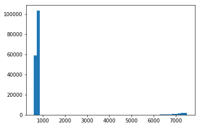

```python
filledScore = no_dup[no_dup['Credit Score'].notnull()]
plt.hist(filledScore['Credit Score'], bins = 50)
plt.show()
```

```python
df_cleaned =no_dup.copy()
df_cleaned['Credit Score']= no_dup['Credit Score'].fillna(no_dup['Credit Score'].median())
```

```python
df_cleaned.head()
```

|  | Loan ID | Customer ID | Loan Status | Current Loan Amount | Term | Credit Score | Years in current job | Home Ownership | Annual Income | Purpose | Monthly Debt | Years of Credit History | Months since last delinquent | Number of Open Accounts | Number of Credit Problems | Current Credit Balance | Maximum Open Credit | Bankruptcies | Tax Liens |
| --- | --- | --- | --- | --- | --- | --- | --- | --- | --- | --- | --- | --- | --- | --- | --- | --- | --- | --- | --- |
| 0 | 000025bb-5694-4cff-b17d-192b1a98ba44 | 5ebc8bb1-5eb9-4404-b11b-a6eebc401a19 | Fully Paid | 11520 | Short Term | 741.0 | 10+ years | Home Mortgage | 33694.0 | Debt Consolidation | $584.03 | 12.3 | 41.0 | 10 | 0 | 6760 | 16056 | 0.0 | 0.0 |
| 128265 | 7f99634c-cc18-4667-92b4-b9e887b7c296 | e52aac79-e3f0-44cf-b538-539c0a01c849 | Fully Paid | 7055 | Short Term | 742.0 | 10+ years | Home Mortgage | 90711.0 | Debt Consolidation | $1,322.87 | 31.9 | 11.0 | 21 | 0 | 18290 | 19752 | 0.0 | 0.0 |
| 128263 | 7f99378c-b36e-4711-9af2-33c7239c00e7 | 32bdbd23-ca78-4c14-a0da-afc2a4e7a33a | Fully Paid | 99999999 | Long Term | 694.0 | 8 years | Home Mortgage | 110549.0 | Debt Consolidation | $1,824.06 | 21.6 | 13.0 | 18 | 0 | 40907 | 52513 | 0.0 | 0.0 |
| 128259 | 7f96d054-5de3-4f5f-9a21-d54ee9af703b | 784a48cb-96ee-494c-aa7b-eb388fbf3003 | Fully Paid | 2745 | Short Term | 743.0 | 2 years | Home Mortgage | 34318.0 | Debt Consolidation | $506.18 | 16.5 | 68.0 | 6 | 0 | 5429 | 10501 | 0.0 | 0.0 |
| 128256 | 7f9558b3-4ed7-4fe0-8662-8021c53c0016 | 0971186f-b0a7-4d11-ba55-4b41348673a2 | Fully Paid | 3008 | Short Term | 750.0 | 2 years | Rent | 37104.0 | Debt Consolidation | $556.55 | 13.8 | 34.0 | 11 | 0 | 732 | 12621 | 0.0 | 0.0 |

```python
df_cleaned['Years in current job'].unique()
```

```
array(['10+ years', '8 years', '2 years', '3 years', '6 years', '1 year',
       '5 years', '4 years', '7 years', '< 1 year', '9 years', nan],
      dtype=object)
```

```python
df_cleaned['Years in current job'].mode()
```

```
0    10+ years
dtype: object
```

```python
df_cleaned[df_cleaned['Years in current job'].isnull()==True]
```

|  | Loan ID | Customer ID | Loan Status | Current Loan Amount | Term | Credit Score | Years in current job | Home Ownership | Annual Income | Purpose | Monthly Debt | Years of Credit History | Months since last delinquent | Number of Open Accounts | Number of Credit Problems | Current Credit Balance | Maximum Open Credit | Bankruptcies | Tax Liens |
| --- | --- | --- | --- | --- | --- | --- | --- | --- | --- | --- | --- | --- | --- | --- | --- | --- | --- | --- | --- |
| 173280 | ac42556a-621c-4efe-accd-81b0f8b88763 | a2a872f7-7f3c-42c1-b293-c47d1c8dcaf1 | Fully Paid | 14413 | Short Term | 742.0 | NaN | Home Mortgage | 62056.0 | Home Improvements | $1,054.95 | 44.3 | 40.0 | 11 | 0 | 15763 | 20209 | 0.0 | 0.0 |
| 173534 | ac805fbc-eed9-4358-acfe-0483ab2bdc4f | 5e18f2ba-6b6b-4d8d-8d17-5e7505f5f2fc | Fully Paid | 99999999 | Short Term | 743.0 | NaN | Rent | 64333.0 | Take a Trip | $456.23 | 20.3 | 35.0 | 7 | 0 | 4361 | 8954 | 0.0 | 0.0 |
| 174092 | ad06660e-ea3c-4065-9a5d-fb5a48a844af | f3f9b937-67ba-4e75-8090-131bc7f8cbb7 | Fully Paid | 99999999 | Short Term | 748.0 | NaN | Home Mortgage | 87084.0 | Debt Consolidation | $957.92 | 17.0 | 27.0 | 17 | 0 | 12442 | 57869 | 0.0 | 0.0 |
| 26896 | 1ae0e1f4-60c6-4057-b7f0-ff7d658c9d8d | 80b73ac5-4596-4fdd-a8b6-c5fc6a549100 | Charged Off | 11797 | Short Term | 746.0 | NaN | Own Home | 49155.0 | Debt Consolidation | $1,151.04 | 27.0 | 61.0 | 10 | 0 | 8812 | 20930 | 0.0 | 0.0 |
| 173682 | aca2383d-d3cb-46e7-97bd-bc0805105db0 | fa638ab0-0f90-40a2-8538-bd6822d4fb13 | Fully Paid | 99999999 | Short Term | 721.0 | NaN | Rent | 63104.0 | Debt Consolidation | $678.36 | 20.0 | 21.0 | 8 | 1 | 8763 | 20145 | 1.0 | 0.0 |
| 173329 | ac4f9423-eb2c-490f-94a5-0c1effa6a797 | 9475ae94-3944-41b0-a533-d925d58e4f23 | Fully Paid | 4080 | Short Term | 676.0 | NaN | Rent | 45900.0 | Business Loan | $284.58 | 27.1 | 61.0 | 7 | 1 | 4969 | 13359 | 1.0 | 0.0 |
| 26937 | 1aed3d3c-2900-4d7c-9d60-9c91c1bb950a | 37d905fe-cbc7-4df3-bf38-deff00d68cf6 | Fully Paid | 2371 | Short Term | 744.0 | NaN | Rent | 8179.0 | Debt Consolidation | $55.35 | 23.5 | 34.0 | 4 | 0 | 1898 | 12822 | 0.0 | 0.0 |
| 173448 | ac6c1ced-3d87-4e5a-937a-30087175e003 | 3ebc9323-fd95-4e37-aed2-1e233dbe1b32 | Charged Off | 9836 | Short Term | 7000.0 | NaN | Home Mortgage | 39344.0 | Debt Consolidation | $439.34 | 22.0 | 0.0 | 10 | 0 | 5255 | 21450 | 0.0 | 0.0 |
| 173426 | ac68d02f-03c0-47bd-9913-4072a6c41bb6 | 902b24c3-47bc-4a24-adee-cc2b2fc4b0ec | Fully Paid | 99999999 | Short Term | 735.0 | NaN | Home Mortgage | 82002.0 | Business Loan | $1,366.70 | 25.8 | 32.0 | 12 | 1 | 14573 | 24826 | 1.0 | 0.0 |
| 173472 | ac732b14-0923-40ee-adc3-5ebf40547c94 | 38414da0-02e4-495e-a681-05d85bf2eec0 | Fully Paid | 15302 | Short Term | 742.0 | NaN | Home Mortgage | 65286.0 | Debt Consolidation | $935.77 | 21.5 | 47.0 | 10 | 0 | 45585 | 51802 | 0.0 | 0.0 |
| 173367 | ac584085-6307-4dc2-8ed5-4cf00a6dfd3c | 93b132cd-104b-4792-8c2f-a28017e87a3e | Fully Paid | 99999999 | Short Term | 731.0 | NaN | Home Mortgage | 28035.0 | Debt Consolidation | $523.33 | 20.8 | 26.0 | 12 | 1 | 3080 | 10441 | 0.0 | 0.0 |
| 173545 | ac838e64-261b-411f-90b0-163c9fef02ac | cf2e394a-863c-4a7c-a51d-a6933db8aa01 | Fully Paid | 20146 | Short Term | 739.0 | NaN | Home Mortgage | 71090.0 | Debt Consolidation | $493.49 | 47.9 | 31.0 | 6 | 1 | 3598 | 11682 | 1.0 | 0.0 |
| 174068 | ad02d96e-b2a2-47ec-8e6f-4db0a77b90f6 | 0f65afd7-d784-4cd0-886f-0f66bbe7ec06 | Fully Paid | 5977 | Short Term | 737.0 | NaN | Home Mortgage | 51404.0 | Debt Consolidation | $582.58 | 19.9 | 16.0 | 8 | 0 | 9561 | 12257 | 0.0 | 0.0 |
| 174080 | ad04a669-3177-450c-adab-f52050f87228 | 5d05676e-9178-4141-be2e-686346c8ec1d | Fully Paid | 15682 | Short Term | 700.0 | NaN | Rent | 73946.0 | Debt Consolidation | $1,429.61 | 28.6 | 32.0 | 9 | 0 | 9543 | 10487 | 0.0 | 0.0 |
| 26952 | 1aef5ca7-71a1-4c6e-af48-3126f0625120 | 4b9dfe28-69ed-41d6-9331-7bdbfe3956cc | Fully Paid | 2928 | Short Term | 746.0 | NaN | Home Mortgage | 24398.0 | Home Improvements | $82.95 | 23.1 | 31.0 | 6 | 1 | 2208 | 10368 | 1.0 | 0.0 |
| 26978 | 1af65a97-17d8-432f-b8b4-17096aa50511 | ad99750e-961d-4e30-8bda-fb2ce53bae3a | Fully Paid | 99999999 | Short Term | 724.0 | NaN | Home Mortgage | 51903.0 | Debt Consolidation | $648.79 | 14.6 | 56.0 | 8 | 0 | 1950 | 3234 | 0.0 | 0.0 |
| 174036 | acfb2377-afe4-49ea-8713-3b778ff88d0a | c8ad7a90-20ab-48a4-b727-4bbe02afca54 | Charged Off | 28003 | Long Term | 644.0 | NaN | Rent | 67978.0 | Other | $1,648.47 | 20.1 | 1.0 | 14 | 0 | 32953 | 40089 | 0.0 | 0.0 |
| 175793 | aec1ac05-fa56-46e7-b56a-cf99f54c10ec | 703e03dd-4975-44bb-9c5a-c829e66a426e | Charged Off | 4996 | Short Term | 714.0 | NaN | Home Mortgage | 21707.0 | Debt Consolidation | $464.90 | 13.6 | 76.0 | 8 | 2 | 7276 | 11987 | 0.0 | 0.0 |
| 248985 | f7f98052-5983-490f-87ef-9dad239d8218 | cbd0ec21-01e5-460f-b4b9-1ca2f9004992 | Fully Paid | 99999999 | Short Term | 701.0 | NaN | Home Mortgage | 44222.0 | other | $420.11 | 32.1 | 23.0 | 10 | 0 | 16845 | 21350 | 0.0 | 0.0 |
| 175826 | aec8a60c-8ce9-4fb1-a010-0e345ea29b82 | 291d3bc3-fc82-4828-9a35-acbaab037520 | Fully Paid | 7800 | Short Term | 720.0 | NaN | Own Home | 68250.0 | Debt Consolidation | $1,302.43 | 26.0 | 18.0 | 7 | 0 | 25542 | 29631 | 0.0 | 0.0 |
| 2505 | 0291642a-3431-42d9-91d2-f840e7edcef0 | 33192245-25ba-4ca5-b19b-733bd54073b1 | Fully Paid | 15899 | Short Term | 733.0 | NaN | Home Mortgage | 70553.0 | Debt Consolidation | $391.57 | 25.7 | 18.0 | 12 | 0 | 14592 | 20757 | 0.0 | 0.0 |
| 175933 | aee5937a-0d6f-408c-a608-eb0f2ca1fb07 | ac49f838-1aff-4066-8b95-66f7aa79a4d1 | Fully Paid | 5125 | Short Term | 719.0 | NaN | Rent | 39210.0 | Other | $229.70 | 31.8 | 41.0 | 9 | 1 | 1186 | 9563 | 1.0 | 0.0 |
| 248932 | f7ec5f42-545d-47f0-9122-ed7de3c98ae5 | 154a15d1-7467-4f93-af69-b139c470239f | Fully Paid | 5765 | Short Term | 744.0 | NaN | Home Mortgage | 51015.0 | Debt Consolidation | $880.01 | 39.6 | 27.0 | 21 | 0 | 44922 | 123751 | 0.0 | 0.0 |
| 175919 | aee07838-218a-4711-8959-2ed1833027a1 | 1ee0c5d8-4232-4a50-8e56-be35d208c57f | Fully Paid | 11942 | Short Term | 739.0 | NaN | Home Mortgage | 89568.0 | other | $1,492.80 | 25.5 | 18.0 | 8 | 0 | 34856 | 283381 | 0.0 | 0.0 |
| 249066 | f80d7079-1cff-4670-a829-f2f7a9ac571f | e1dfc891-91d4-4d73-9e42-b914eb293189 | Fully Paid | 12011 | Short Term | 738.0 | NaN | Home Mortgage | 58921.0 | Debt Consolidation | $819.99 | 20.9 | 18.0 | 11 | 0 | 15807 | 23076 | 0.0 | 0.0 |
| 249095 | f8141615-1977-4e65-98e3-4b873efe077e | ac19299a-9247-4032-80df-6ed7a0684573 | Fully Paid | 3991 | Short Term | 734.0 | NaN | Own Home | 14975.0 | Buy a Car | $49.92 | 17.0 | 44.0 | 4 | 0 | 738 | 23818 | 0.0 | 0.0 |
| 175635 | ae9909fc-3fd1-4cc2-b60d-39b5dc7739de | 6c3f8d54-e607-4b8e-906a-217946623698 | Charged Off | 7838 | Short Term | 720.0 | NaN | Home Mortgage | 37866.0 | Debt Consolidation | $798.34 | 48.5 | 57.0 | 9 | 1 | 3084 | 6295 | 1.0 | 0.0 |
| 26152 | 1a1a418d-fe50-43c5-a415-52ec77aada88 | 0e7c0a01-244a-43e1-9d71-d8d1237ac7d2 | Fully Paid | 99999999 | Short Term | 715.0 | NaN | Rent | 15321.0 | Debt Consolidation | $90.90 | 11.3 | 25.0 | 6 | 0 | 2719 | 2859 | 0.0 | 0.0 |
| 176405 | af5a650b-af73-41fa-a9a0-86e480e1aa84 | 18918911-3c03-4f3f-a679-a3d30880a261 | Fully Paid | 9846 | Short Term | 734.0 | NaN | Own Home | 25600.0 | Debt Consolidation | $509.86 | 18.1 | 14.0 | 7 | 0 | 5848 | 7776 | 0.0 | 0.0 |
| 26075 | 1a07527b-d426-4df9-a90d-561a0e77e121 | 1af45f46-23b3-44c2-918f-d3ea94de0ecd | Charged Off | 23402 | Short Term | 7260.0 | NaN | Own Home | 63382.0 | Debt Consolidation | $1,061.64 | 45.6 | 57.0 | 8 | 0 | 29071 | 31092 | 0.0 | 0.0 |
| ... | ... | ... | ... | ... | ... | ... | ... | ... | ... | ... | ... | ... | ... | ... | ... | ... | ... | ... | ... |
| 210653 | d199168d-74e1-4a91-8977-4a92abd3b7e6 | ff0ec39b-ed73-4621-b3d0-37ca5ebdd781 | Fully Paid | 4660 | Short Term | 733.0 | NaN | Home Mortgage | NaN | Debt Consolidation | $410.56 | 24.6 | NaN | 9 | 1 | 4027 | 6601 | 0.0 | 1.0 |
| 196939 | c3d122fb-82f9-49aa-a53b-fcaa0c5005cc | db5157da-7f78-467e-9ad6-ac59a02ba37a | Fully Paid | 4021 | Short Term | 733.0 | NaN | Home Mortgage | NaN | Debt Consolidation | $714.70 | 17.6 | NaN | 10 | 1 | 7124 | 12054 | 1.0 | 0.0 |
| 73942 | 49754fb6-c9f7-47e1-82bc-8e36a0601e34 | d7568176-b747-45ac-a37c-5f1ac79a3e88 | Fully Paid | 12289 | Long Term | 733.0 | NaN | Rent | NaN | Debt Consolidation | $410.03 | 8.9 | NaN | 13 | 0 | 4700 | 13663 | 0.0 | 0.0 |
| 183394 | b65c390f-f654-4fd3-aee3-0d5a90ceaa57 | cdadacf2-762c-4d72-9b71-45d8daa3b57f | Fully Paid | 10664 | Short Term | 733.0 | NaN | Rent | NaN | Debt Consolidation | $554.43 | 16.0 | NaN | 14 | 0 | 17322 | 27760 | 0.0 | 0.0 |
| 5598 | 0598ffd1-01b8-4cf8-a189-1aa921e04cc9 | 5b07ab32-4213-4641-8848-8b8909e978f9 | Fully Paid | 4052 | Short Term | 733.0 | NaN | Rent | NaN | Debt Consolidation | $196.00 | 11.0 | NaN | 6 | 0 | 5491 | 7595 | 0.0 | 0.0 |
| 121922 | 792b4481-31b8-4ab8-82d3-0a884d97b3ef | a671bd7f-633b-4dd5-8e8d-e6857f71f26f | Fully Paid | 28398 | Long Term | 733.0 | NaN | Rent | NaN | Debt Consolidation | $1,899.93 | 42.4 | NaN | 16 | 0 | 28759 | 43182 | 0.0 | 0.0 |
| 188655 | bba2d454-4163-4a97-a951-ee7a1c6b0671 | 40b9912e-5fff-4da0-b09a-6a7cd7fe4b64 | Fully Paid | 9996 | Short Term | 733.0 | NaN | Home Mortgage | NaN | Debt Consolidation | $823.00 | 24.4 | NaN | 16 | 0 | 8674 | 37386 | 0.0 | 0.0 |
| 5602 | 059a48b2-92a0-4419-92b9-58e0c76a73d7 | 034ddee5-6b1f-4967-a482-3992d25180d0 | Charged Off | 19548 | Short Term | 733.0 | NaN | Home Mortgage | NaN | Debt Consolidation | $626.76 | 29.0 | NaN | 11 | 0 | 21502 | 36819 | 0.0 | 0.0 |
| 134137 | 85670bd6-c686-48ca-b2f6-0d54d0eafb3b | 2af61bd7-d7dc-4c1d-846f-f8e9be45c420 | Fully Paid | 1803 | Short Term | 733.0 | NaN | Rent | NaN | Debt Consolidation | $295.44 | 19.7 | NaN | 11 | 0 | 14797 | 26236 | 0.0 | 0.0 |
| 225482 | e04e59f3-45da-41b8-9103-33d9f78287ee | 08a02c9a-4dc1-4c1f-91fa-e2782132551c | Charged Off | 5042 | Short Term | 733.0 | NaN | Home Mortgage | NaN | other | $1,329.27 | 13.4 | NaN | 13 | 0 | 21420 | 21924 | 0.0 | 0.0 |
| 192595 | bf86c30a-6bc9-4c3e-92e4-d0f28ddf3c3f | 5e6e1943-cb63-4e56-8850-7b45945b3574 | Fully Paid | 15428 | Short Term | 733.0 | NaN | Rent | NaN | Debt Consolidation | $659.17 | 22.1 | NaN | 7 | 0 | 9843 | 11236 | 0.0 | 0.0 |
| 83235 | 52a7f035-1628-4d2f-acfb-0e18102900c5 | 6fcd2b59-3263-4978-9f24-541ae5cd1d85 | Fully Paid | 5001 | Short Term | 733.0 | NaN | Rent | NaN | Debt Consolidation | $458.09 | 9.4 | NaN | 9 | 1 | 4573 | 7597 | 1.0 | 0.0 |
| 161673 | a0d13d77-5adc-4d4b-b5c4-54e027e53b9f | e09b780c-295d-4770-b62f-b1b9b0d45b12 | Fully Paid | 19904 | Short Term | 733.0 | NaN | Home Mortgage | NaN | Debt Consolidation | $442.50 | 38.2 | NaN | 9 | 0 | 22304 | 58085 | 0.0 | 0.0 |
| 112872 | 7017e2bf-addf-4921-8a5c-83033aa4ba5f | 55f04f74-db14-45a7-a93b-b650d887f3a6 | Fully Paid | 14792 | Short Term | 733.0 | NaN | Rent | NaN | Debt Consolidation | $1,756.26 | 18.0 | NaN | 8 | 0 | 33082 | 53617 | 0.0 | 0.0 |
| 62660 | 3e5bb348-a284-4677-9ca0-41d2d11d2296 | 7adca112-4d41-446f-9a32-3d9b62d86c31 | Fully Paid | 5996 | Short Term | 733.0 | NaN | Own Home | NaN | Buy House | $25.05 | 16.9 | NaN | 4 | 0 | 324 | 19048 | 0.0 | 0.0 |
| 237038 | ebda9fc3-2adc-4686-ab07-0b07a62d2f37 | 20f60f2f-8185-4948-9bc6-cff6d694cf45 | Fully Paid | 3334 | Short Term | 733.0 | NaN | Rent | NaN | Debt Consolidation | $357.22 | 29.0 | NaN | 11 | 0 | 3551 | 72460 | 0.0 | 0.0 |
| 37017 | 24de2115-2b17-4f7c-a83a-de4e01719087 | 65bdda98-3efd-4c62-ade5-17413dfd00ab | Fully Paid | 5090 | Short Term | 733.0 | NaN | Home Mortgage | NaN | Debt Consolidation | $267.16 | 10.3 | NaN | 4 | 0 | 4582 | 6005 | 0.0 | 0.0 |
| 37000 | 24dac85e-c66d-47ff-8114-babaee373c09 | 2d2f7df5-602b-4db4-aebc-5ab579232e6d | Fully Paid | 5928 | Short Term | 733.0 | NaN | Rent | NaN | Debt Consolidation | $101.74 | 19.9 | NaN | 5 | 1 | 3439 | 10421 | 1.0 | 0.0 |
| 183515 | b67a2be4-b538-417c-9ff0-52dae0f57255 | effb3d59-f5b1-4249-968f-a507bc1547b0 | Fully Paid | 6837 | Short Term | 733.0 | NaN | Home Mortgage | NaN | Debt Consolidation | $935.33 | 17.7 | NaN | 9 | 0 | 16108 | 25287 | 0.0 | 0.0 |
| 247357 | f65e7d75-a80c-4e1f-b0e0-49e55726b2ca | 550a58d6-5961-44e5-94a7-09c0e296a4b6 | Fully Paid | 2020 | Short Term | 733.0 | NaN | Home Mortgage | NaN | Home Improvements | $168.70 | 24.0 | NaN | 4 | 0 | 6497 | 6767 | 0.0 | 0.0 |
| 80610 | 5010f786-7b3d-4aac-bc53-01d1bf673abd | 1f410f88-3edd-4036-9038-628260ec9eab | Fully Paid | 11598 | Short Term | 733.0 | NaN | Home Mortgage | NaN | Debt Consolidation | $420.63 | 39.3 | NaN | 9 | 0 | 3865 | 9884 | 0.0 | 0.0 |
| 112851 | 7011f892-0c94-4249-bf76-1d037cea6439 | 7a92e24d-10f3-496b-8dd9-b9f6bde65d36 | Fully Paid | 3058 | Short Term | 733.0 | NaN | HaveMortgage | NaN | Take a Trip | $1,166.91 | 27.4 | NaN | 8 | 0 | 35654 | 61791 | 0.0 | 0.0 |
| 99591 | 62f59cb7-d5e2-48e0-a641-a34f12966770 | 113b1587-82c1-4460-87fa-1948108ce818 | Fully Paid | 11046 | Short Term | 733.0 | NaN | Rent | NaN | Debt Consolidation | $508.99 | 12.7 | NaN | 10 | 0 | 16524 | 18319 | 0.0 | 0.0 |
| 35740 | 239eddda-a017-4052-a54f-ddf602c53055 | 9190a4e4-edcc-4529-99f3-e06b8e60c42f | Fully Paid | 7878 | Short Term | 733.0 | NaN | Own Home | NaN | Debt Consolidation | $307.08 | 41.7 | NaN | 12 | 0 | 9432 | 82022 | 0.0 | 0.0 |
| 222347 | dd43d4cf-f75b-4496-ae50-5db390b11c14 | e5d9d904-6bb2-4475-8e4a-e7538955793e | Charged Off | 18011 | Short Term | 733.0 | NaN | Home Mortgage | NaN | Debt Consolidation | $790.45 | 20.0 | NaN | 7 | 0 | 27619 | 34567 | 0.0 | 0.0 |
| 136736 | 880944f8-112e-477b-aba4-607adf7354ae | b1b314ce-f59d-4a02-917c-af1dd1d3c0f8 | Fully Paid | 10470 | Long Term | 733.0 | NaN | Rent | NaN | Debt Consolidation | $254.19 | 9.9 | NaN | 4 | 0 | 8419 | 8617 | 0.0 | 0.0 |
| 210603 | d18e1dcf-b1b0-48ea-b618-0f8e68b78d95 | e02cd691-2e14-4160-8f48-60722ef13e56 | Fully Paid | 7997 | Short Term | 733.0 | NaN | Rent | NaN | Debt Consolidation | $487.97 | 9.1 | NaN | 15 | 0 | 10573 | 25114 | 0.0 | 0.0 |
| 201198 | c827d04f-37c2-4ea5-8ea7-07941ee84c56 | 4d5379f1-4e8f-42fa-89cb-66a5a721f4dd | Fully Paid | 11860 | Short Term | 733.0 | NaN | Rent | NaN | Debt Consolidation | $193.69 | 16.2 | NaN | 5 | 0 | 8339 | 17089 | 0.0 | 0.0 |
| 128143 | 7f78cf95-560e-4c5a-9363-badced6777fa | 76dcd93e-3fa8-4af3-a975-c32eca83059e | Fully Paid | 2018 | Short Term | 733.0 | NaN | Home Mortgage | NaN | Medical Bills | $800.68 | 14.5 | NaN | 17 | 0 | 21697 | 41249 | 0.0 | 0.0 |
| 130205 | 818f9bb4-15a4-4c64-a18f-eb403a20bb74 | f3bf0af3-2746-4419-bed1-dbc488eef769 | Fully Paid | 1976 | Short Term | 733.0 | NaN | Rent | NaN | Debt Consolidation | $166.00 | 9.6 | NaN | 4 | 0 | 5175 | 10780 | 0.0 | 0.0 |

8990 rows × 19 columns

```python
df_cleaned['Null years in current job'] = df_cleaned['Years in current job'].isnull()
```

```python
df_cleaned.head()
```

|  | Loan ID | Customer ID | Loan Status | Current Loan Amount | Term | Credit Score | Years in current job | Home Ownership | Annual Income | Purpose | Monthly Debt | Years of Credit History | Months since last delinquent | Number of Open Accounts | Number of Credit Problems | Current Credit Balance | Maximum Open Credit | Bankruptcies | Tax Liens | Null years in current job |
| --- | --- | --- | --- | --- | --- | --- | --- | --- | --- | --- | --- | --- | --- | --- | --- | --- | --- | --- | --- | --- |
| 0 | 000025bb-5694-4cff-b17d-192b1a98ba44 | 5ebc8bb1-5eb9-4404-b11b-a6eebc401a19 | Fully Paid | 11520 | Short Term | 741.0 | 10+ years | Home Mortgage | 33694.0 | Debt Consolidation | $584.03 | 12.3 | 41.0 | 10 | 0 | 6760 | 16056 | 0.0 | 0.0 | False |
| 128265 | 7f99634c-cc18-4667-92b4-b9e887b7c296 | e52aac79-e3f0-44cf-b538-539c0a01c849 | Fully Paid | 7055 | Short Term | 742.0 | 10+ years | Home Mortgage | 90711.0 | Debt Consolidation | $1,322.87 | 31.9 | 11.0 | 21 | 0 | 18290 | 19752 | 0.0 | 0.0 | False |
| 128263 | 7f99378c-b36e-4711-9af2-33c7239c00e7 | 32bdbd23-ca78-4c14-a0da-afc2a4e7a33a | Fully Paid | 99999999 | Long Term | 694.0 | 8 years | Home Mortgage | 110549.0 | Debt Consolidation | $1,824.06 | 21.6 | 13.0 | 18 | 0 | 40907 | 52513 | 0.0 | 0.0 | False |
| 128259 | 7f96d054-5de3-4f5f-9a21-d54ee9af703b | 784a48cb-96ee-494c-aa7b-eb388fbf3003 | Fully Paid | 2745 | Short Term | 743.0 | 2 years | Home Mortgage | 34318.0 | Debt Consolidation | $506.18 | 16.5 | 68.0 | 6 | 0 | 5429 | 10501 | 0.0 | 0.0 | False |
| 128256 | 7f9558b3-4ed7-4fe0-8662-8021c53c0016 | 0971186f-b0a7-4d11-ba55-4b41348673a2 | Fully Paid | 3008 | Short Term | 750.0 | 2 years | Rent | 37104.0 | Debt Consolidation | $556.55 | 13.8 | 34.0 | 11 | 0 | 732 | 12621 | 0.0 | 0.0 | False |

```python
df_cleaned['Years in current job'] = df_cleaned['Years in current job'].fillna('0')
```

```python
df_cleaned[df_cleaned['Years in current job'].isnull()==True]
```

|  | Loan ID | Customer ID | Loan Status | Current Loan Amount | Term | Credit Score | Years in current job | Home Ownership | Annual Income | Purpose | Monthly Debt | Years of Credit History | Months since last delinquent | Number of Open Accounts | Number of Credit Problems | Current Credit Balance | Maximum Open Credit | Bankruptcies | Tax Liens | Null years in current job |
| --- | --- | --- | --- | --- | --- | --- | --- | --- | --- | --- | --- | --- | --- | --- | --- | --- | --- | --- | --- | --- |

```python
df_cleaned.iloc[9]
```

```
Loan ID                         7f8fea60-ef3a-409b-84b8-f0f9e501293b
Customer ID                     f3c67c03-d825-451d-a1b1-a3c9ec3757a3
Loan Status                                               Fully Paid
Current Loan Amount                                         99999999
Term                                                      Short Term
Credit Score                                                     745
Years in current job                                         6 years
Home Ownership                                         Home Mortgage
Annual Income                                                  55258
Purpose                                                        other
Monthly Debt                                                 $915.90
Years of Credit History                                           25
Months since last delinquent                                      81
Number of Open Accounts                                            9
Number of Credit Problems                                          0
Current Credit Balance                                         16559
Maximum Open Credit                                            19760
Bankruptcies                                                       0
Tax Liens                                                          0
Null years in current job                                      False
Name: 128242, dtype: object
```

```python
df_cleaned['Years in current job'][df_cleaned['Years in current job']=='< 1 year']='0'
```

```python
df_cleaned['Years in current job'].unique()
```

```
array(['10+ years', '8 years', '2 years', '3 years', '6 years', '1 year',
       '5 years', '4 years', '7 years', '0', '9 years'], dtype=object)
```

```python
df_cleaned['Over ten years'] = df_cleaned['Years in current job']==('10+ years')
```

```python
df_cleaned.head()
```

|  | Loan ID | Customer ID | Loan Status | Current Loan Amount | Term | Credit Score | Years in current job | Home Ownership | Annual Income | Purpose | ... | Years of Credit History | Months since last delinquent | Number of Open Accounts | Number of Credit Problems | Current Credit Balance | Maximum Open Credit | Bankruptcies | Tax Liens | Null years in current job | Over ten years |
| --- | --- | --- | --- | --- | --- | --- | --- | --- | --- | --- | --- | --- | --- | --- | --- | --- | --- | --- | --- | --- | --- |
| 0 | 000025bb-5694-4cff-b17d-192b1a98ba44 | 5ebc8bb1-5eb9-4404-b11b-a6eebc401a19 | Fully Paid | 11520 | Short Term | 741.0 | 10+ years | Home Mortgage | 33694.0 | Debt Consolidation | ... | 12.3 | 41.0 | 10 | 0 | 6760 | 16056 | 0.0 | 0.0 | False | True |
| 128265 | 7f99634c-cc18-4667-92b4-b9e887b7c296 | e52aac79-e3f0-44cf-b538-539c0a01c849 | Fully Paid | 7055 | Short Term | 742.0 | 10+ years | Home Mortgage | 90711.0 | Debt Consolidation | ... | 31.9 | 11.0 | 21 | 0 | 18290 | 19752 | 0.0 | 0.0 | False | True |
| 128263 | 7f99378c-b36e-4711-9af2-33c7239c00e7 | 32bdbd23-ca78-4c14-a0da-afc2a4e7a33a | Fully Paid | 99999999 | Long Term | 694.0 | 8 years | Home Mortgage | 110549.0 | Debt Consolidation | ... | 21.6 | 13.0 | 18 | 0 | 40907 | 52513 | 0.0 | 0.0 | False | False |
| 128259 | 7f96d054-5de3-4f5f-9a21-d54ee9af703b | 784a48cb-96ee-494c-aa7b-eb388fbf3003 | Fully Paid | 2745 | Short Term | 743.0 | 2 years | Home Mortgage | 34318.0 | Debt Consolidation | ... | 16.5 | 68.0 | 6 | 0 | 5429 | 10501 | 0.0 | 0.0 | False | False |
| 128256 | 7f9558b3-4ed7-4fe0-8662-8021c53c0016 | 0971186f-b0a7-4d11-ba55-4b41348673a2 | Fully Paid | 3008 | Short Term | 750.0 | 2 years | Rent | 37104.0 | Debt Consolidation | ... | 13.8 | 34.0 | 11 | 0 | 732 | 12621 | 0.0 | 0.0 | False | False |

5 rows × 21 columns

```python
df_cleaned['Years in current job'][df_cleaned['Years in current job']=='10+ years']='0'
```

```python
df_cleaned['Years in current job'].unique()
```

```
array(['0', '8 years', '2 years', '3 years', '6 years', '1 year',
       '5 years', '4 years', '7 years', '9 years'], dtype=object)
```

```python
df_cleaned['Years in current job'] = df_cleaned['Years in current job'].apply(lambda x:x[0])
```

```python
df_cleaned.head()
```

|  | Loan ID | Customer ID | Loan Status | Current Loan Amount | Term | Credit Score | Years in current job | Home Ownership | Annual Income | Purpose | ... | Years of Credit History | Months since last delinquent | Number of Open Accounts | Number of Credit Problems | Current Credit Balance | Maximum Open Credit | Bankruptcies | Tax Liens | Null years in current job | Over ten years |
| --- | --- | --- | --- | --- | --- | --- | --- | --- | --- | --- | --- | --- | --- | --- | --- | --- | --- | --- | --- | --- | --- |
| 0 | 000025bb-5694-4cff-b17d-192b1a98ba44 | 5ebc8bb1-5eb9-4404-b11b-a6eebc401a19 | Fully Paid | 11520 | Short Term | 741.0 | 0 | Home Mortgage | 33694.0 | Debt Consolidation | ... | 12.3 | 41.0 | 10 | 0 | 6760 | 16056 | 0.0 | 0.0 | False | True |
| 128265 | 7f99634c-cc18-4667-92b4-b9e887b7c296 | e52aac79-e3f0-44cf-b538-539c0a01c849 | Fully Paid | 7055 | Short Term | 742.0 | 0 | Home Mortgage | 90711.0 | Debt Consolidation | ... | 31.9 | 11.0 | 21 | 0 | 18290 | 19752 | 0.0 | 0.0 | False | True |
| 128263 | 7f99378c-b36e-4711-9af2-33c7239c00e7 | 32bdbd23-ca78-4c14-a0da-afc2a4e7a33a | Fully Paid | 99999999 | Long Term | 694.0 | 8 | Home Mortgage | 110549.0 | Debt Consolidation | ... | 21.6 | 13.0 | 18 | 0 | 40907 | 52513 | 0.0 | 0.0 | False | False |
| 128259 | 7f96d054-5de3-4f5f-9a21-d54ee9af703b | 784a48cb-96ee-494c-aa7b-eb388fbf3003 | Fully Paid | 2745 | Short Term | 743.0 | 2 | Home Mortgage | 34318.0 | Debt Consolidation | ... | 16.5 | 68.0 | 6 | 0 | 5429 | 10501 | 0.0 | 0.0 | False | False |
| 128256 | 7f9558b3-4ed7-4fe0-8662-8021c53c0016 | 0971186f-b0a7-4d11-ba55-4b41348673a2 | Fully Paid | 3008 | Short Term | 750.0 | 2 | Rent | 37104.0 | Debt Consolidation | ... | 13.8 | 34.0 | 11 | 0 | 732 | 12621 | 0.0 | 0.0 | False | False |

5 rows × 21 columns

```python
df_cleaned['Years in current job']=df_cleaned['Years in current job'].astype(int)
```

```python
df_cleaned.info()
```

```
<class 'pandas.core.frame.DataFrame'>
Int64Index: 215700 entries, 0 to 25243
Data columns (total 21 columns):
Loan ID                         215700 non-null object
Customer ID                     215700 non-null object
Loan Status                     215700 non-null object
Current Loan Amount             215700 non-null int64
Term                            215700 non-null object
Credit Score                    215700 non-null float64
Years in current job            215700 non-null int32
Home Ownership                  215700 non-null object
Annual Income                   171202 non-null float64
Purpose                         215700 non-null object
Monthly Debt                    215700 non-null object
Years of Credit History         215700 non-null float64
Months since last delinquent    97438 non-null float64
Number of Open Accounts         215700 non-null int64
Number of Credit Problems       215700 non-null int64
Current Credit Balance          215700 non-null int64
Maximum Open Credit             215700 non-null object
Bankruptcies                    215248 non-null float64
Tax Liens                       215678 non-null float64
Null years in current job       215700 non-null bool
Over ten years                  215700 non-null bool
dtypes: bool(2), float64(6), int32(1), int64(4), object(8)
memory usage: 32.5+ MB
```

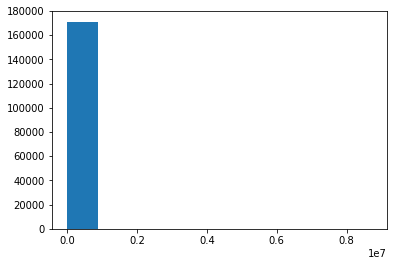

```python
filledIncome = df_cleaned[df_cleaned['Annual Income'].notnull()]
plt.hist(filledIncome['Annual Income'], bins = 10)
plt.show()
```

```python
df_cleaned['Annual Income'].median()
```

```
62105.0
```

```python
df_cleaned['Annual Income']= df_cleaned['Annual Income'].fillna(df_cleaned['Annual Income'].median())
```

```python
df_cleaned['Annual Income'].isnull().sum()
```

```
0
```

```python
df_cleaned['Months since last delinquent'].unique()
```

```
array([ 41.,  11.,  13.,  68.,  34.,   5.,  55.,  17.,  14.,  81.,  36.,
        40.,   6.,  12.,  78.,   8.,  18.,  28.,  35.,  16.,  49.,  24.,
        53.,  15.,  63.,  70.,  52.,  43.,  22.,  30.,  29.,  74.,  10.,
         4.,  48.,  67.,   7.,  73.,   3.,  42.,  21.,  31.,  79.,  44.,
        54.,  27.,  61.,  65.,  25.,  19.,  80.,  57.,  51.,  32.,  75.,
        62.,   2.,  23.,  64.,  37.,  26.,  66.,  59.,  82.,  46.,   9.,
        20.,  76.,  58.,  47.,  60.,  56.,  45.,  71.,  77., 115.,  50.,
        39.,  69.,  33.,  72.,  38.,   1.,   0.,  85.,  89.,  96.,  83.,
       140.,  91., 114., 143.,  94.,  95.,  86.,  88.,  84.,  98., 135.,
       100.,  97.,  93.,  99., 130., 106.,  87., 122.,  92., 101., 152.,
       139., 148., 109., 134., 113., 131., 119., 133., 110., 120.,  90.,
       102., 151., 176., 149., 116., 104., 107.,  nan, 118., 112., 108.])
```

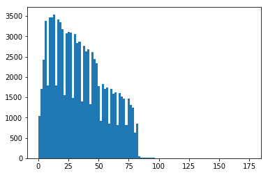

```python
filledMon = df_cleaned[df_cleaned['Months since last delinquent'].notnull()]
plt.hist(filledMon['Months since last delinquent'], bins = 100)
plt.show()
```

```python
df_cleaned['Months since last delinquent'].median()
```

```
32.0
```

```python
df_cleaned['Months since last delinquent']=df_cleaned['Months since last delinquent'].fillna(32.0)
#seperate column for null
```

```python
df_cleaned['Bankruptcies'].unique()
```

```
array([ 0.,  1.,  3.,  2.,  4.,  5.,  7.,  6., nan])
```

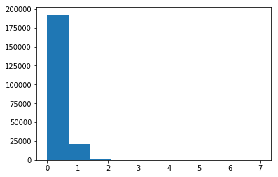

```python
filledBank = df_cleaned[df_cleaned['Bankruptcies'].notnull()]
plt.hist(filledBank['Bankruptcies'], bins = 10)
plt.show()
```

```python
df_cleaned['Bankruptcies'].median()
```

```
0.0
```

```python
df_cleaned['Bankruptcies'] = df_cleaned['Bankruptcies'].fillna(0.0)
```

```python
df_cleaned.head()
```

|  | Loan ID | Customer ID | Loan Status | Current Loan Amount | Term | Credit Score | Years in current job | Home Ownership | Annual Income | Purpose | ... | Years of Credit History | Months since last delinquent | Number of Open Accounts | Number of Credit Problems | Current Credit Balance | Maximum Open Credit | Bankruptcies | Tax Liens | Null years in current job | Over ten years |
| --- | --- | --- | --- | --- | --- | --- | --- | --- | --- | --- | --- | --- | --- | --- | --- | --- | --- | --- | --- | --- | --- |
| 0 | 000025bb-5694-4cff-b17d-192b1a98ba44 | 5ebc8bb1-5eb9-4404-b11b-a6eebc401a19 | Fully Paid | 11520 | Short Term | 741.0 | 0 | Home Mortgage | 33694.0 | Debt Consolidation | ... | 12.3 | 41.0 | 10 | 0 | 6760 | 16056 | 0.0 | 0.0 | False | True |
| 128265 | 7f99634c-cc18-4667-92b4-b9e887b7c296 | e52aac79-e3f0-44cf-b538-539c0a01c849 | Fully Paid | 7055 | Short Term | 742.0 | 0 | Home Mortgage | 90711.0 | Debt Consolidation | ... | 31.9 | 11.0 | 21 | 0 | 18290 | 19752 | 0.0 | 0.0 | False | True |
| 128263 | 7f99378c-b36e-4711-9af2-33c7239c00e7 | 32bdbd23-ca78-4c14-a0da-afc2a4e7a33a | Fully Paid | 99999999 | Long Term | 694.0 | 8 | Home Mortgage | 110549.0 | Debt Consolidation | ... | 21.6 | 13.0 | 18 | 0 | 40907 | 52513 | 0.0 | 0.0 | False | False |
| 128259 | 7f96d054-5de3-4f5f-9a21-d54ee9af703b | 784a48cb-96ee-494c-aa7b-eb388fbf3003 | Fully Paid | 2745 | Short Term | 743.0 | 2 | Home Mortgage | 34318.0 | Debt Consolidation | ... | 16.5 | 68.0 | 6 | 0 | 5429 | 10501 | 0.0 | 0.0 | False | False |
| 128256 | 7f9558b3-4ed7-4fe0-8662-8021c53c0016 | 0971186f-b0a7-4d11-ba55-4b41348673a2 | Fully Paid | 3008 | Short Term | 750.0 | 2 | Rent | 37104.0 | Debt Consolidation | ... | 13.8 | 34.0 | 11 | 0 | 732 | 12621 | 0.0 | 0.0 | False | False |

5 rows × 21 columns

```python
df_cleaned['Bankruptcies'].isnull().sum()
```

```
0
```

```python
df_cleaned['Tax Liens'].unique()
```

```
array([ 0.,  2.,  1.,  3.,  5.,  4.,  9.,  6.,  7.,  8., 10., 11., nan])
```

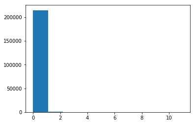

```python
filledLiens = df_cleaned[df_cleaned['Tax Liens'].notnull()]
plt.hist(filledLiens['Tax Liens'], bins = 10)
plt.show()
```

```python
df_cleaned['Tax Liens'] = df_cleaned['Tax Liens'].fillna(df_cleaned['Tax Liens'].median())
```

```python
df_cleaned.head()
```

|  | Loan ID | Customer ID | Loan Status | Current Loan Amount | Term | Credit Score | Years in current job | Home Ownership | Annual Income | Purpose | ... | Years of Credit History | Months since last delinquent | Number of Open Accounts | Number of Credit Problems | Current Credit Balance | Maximum Open Credit | Bankruptcies | Tax Liens | Null years in current job | Over ten years |
| --- | --- | --- | --- | --- | --- | --- | --- | --- | --- | --- | --- | --- | --- | --- | --- | --- | --- | --- | --- | --- | --- |
| 0 | 000025bb-5694-4cff-b17d-192b1a98ba44 | 5ebc8bb1-5eb9-4404-b11b-a6eebc401a19 | Fully Paid | 11520 | Short Term | 741.0 | 0 | Home Mortgage | 33694.0 | Debt Consolidation | ... | 12.3 | 41.0 | 10 | 0 | 6760 | 16056 | 0.0 | 0.0 | False | True |
| 128265 | 7f99634c-cc18-4667-92b4-b9e887b7c296 | e52aac79-e3f0-44cf-b538-539c0a01c849 | Fully Paid | 7055 | Short Term | 742.0 | 0 | Home Mortgage | 90711.0 | Debt Consolidation | ... | 31.9 | 11.0 | 21 | 0 | 18290 | 19752 | 0.0 | 0.0 | False | True |
| 128263 | 7f99378c-b36e-4711-9af2-33c7239c00e7 | 32bdbd23-ca78-4c14-a0da-afc2a4e7a33a | Fully Paid | 99999999 | Long Term | 694.0 | 8 | Home Mortgage | 110549.0 | Debt Consolidation | ... | 21.6 | 13.0 | 18 | 0 | 40907 | 52513 | 0.0 | 0.0 | False | False |
| 128259 | 7f96d054-5de3-4f5f-9a21-d54ee9af703b | 784a48cb-96ee-494c-aa7b-eb388fbf3003 | Fully Paid | 2745 | Short Term | 743.0 | 2 | Home Mortgage | 34318.0 | Debt Consolidation | ... | 16.5 | 68.0 | 6 | 0 | 5429 | 10501 | 0.0 | 0.0 | False | False |
| 128256 | 7f9558b3-4ed7-4fe0-8662-8021c53c0016 | 0971186f-b0a7-4d11-ba55-4b41348673a2 | Fully Paid | 3008 | Short Term | 750.0 | 2 | Rent | 37104.0 | Debt Consolidation | ... | 13.8 | 34.0 | 11 | 0 | 732 | 12621 | 0.0 | 0.0 | False | False |

5 rows × 21 columns

Double check to make sure that there are no more missing values

```python
df_cleaned.isnull().sum()
```

```
Loan ID                         0
Customer ID                     0
Loan Status                     0
Current Loan Amount             0
Term                            0
Credit Score                    0
Years in current job            0
Home Ownership                  0
Annual Income                   0
Purpose                         0
Monthly Debt                    0
Years of Credit History         0
Months since last delinquent    0
Number of Open Accounts         0
Number of Credit Problems       0
Current Credit Balance          0
Maximum Open Credit             0
Bankruptcies                    0
Tax Liens                       0
Null years in current job       0
Over ten years                  0
dtype: int64
```

Analye the unique values of each column to check for spelling mistakes and other mistakes that might affect the model

```python
for item in df_cleaned.columns:
    print(item + ' '+ df[item].dtype.kind)
    print(df_cleaned[item].unique())
```

```
Loan ID O
['000025bb-5694-4cff-b17d-192b1a98ba44'
 '7f99634c-cc18-4667-92b4-b9e887b7c296'
 '7f99378c-b36e-4711-9af2-33c7239c00e7' ...
 '7f78cf95-560e-4c5a-9363-badced6777fa'
 '818f9bb4-15a4-4c64-a18f-eb403a20bb74'
 '193d7f29-89f9-4c59-9e44-c1ca8ea36209']
Customer ID O
['5ebc8bb1-5eb9-4404-b11b-a6eebc401a19'
 'e52aac79-e3f0-44cf-b538-539c0a01c849'
 '32bdbd23-ca78-4c14-a0da-afc2a4e7a33a' ...
 '76dcd93e-3fa8-4af3-a975-c32eca83059e'
 'f3bf0af3-2746-4419-bed1-dbc488eef769'
 '3b462912-a081-4407-a1b1-3553a29bb974']
Loan Status O
['Fully Paid' 'Charged Off']
Current Loan Amount i
[   11520     7055 99999999 ...    20512     1089     2216]
Term O
['Short Term' 'Long Term']
Credit Score f
[ 741.  742.  694.  743.  750. 7400.  717. 6910.  740.  745.  731.  732.
  687.  689.  716.  736.  724.  690.  734.  680.  723.  726. 7410.  692.
  730.  739.  703. 7500.  735.  662.  747.  722.  713.  738.  659.  711.
  658.  702.  696.  718.  681.  709.  720.  728.  729.  695.  733.  708.
  748.  697.  626.  701.  725.  700.  649.  698.  714.  712.  749.  746.
  707.  634.  710.  627.  744. 6890.  668.  652.  706.  640.  751.  737.
  647.  721.  715. 7270.  633.  641. 7260.  705.  686.  727.  671.  675.
  663.  699.  693.  679.  664. 6700.  644.  666.  676. 7080.  669.  684.
  665. 7150.  645.  691.  683.  719.  660. 7430. 6960.  667. 7240.  639.
  704.  597. 7300. 7210. 6800.  638.  688. 7420.  651.  656.  620. 6990.
 7330.  643. 7450.  677.  590.  661. 7360.  630. 6920. 7130.  685.  608.
  674.  648.  673. 7040.  617.  625. 7010. 7470. 6660. 7370.  678.  618.
  637. 7280. 6650.  607.  655.  602.  682.  654.  599. 6300.  603. 6740.
 6980. 7250. 7390.  610. 7380. 7140.  670. 6480.  646. 5960.  672. 6860.
 7440.  636. 7290.  600.  657.  624. 7070. 7350. 7310. 6940. 6540. 6830.
 6080. 6470. 6770. 7020. 7320.  635.  585.  596.  621.  611. 7090. 6580.
  605.  632. 6350. 6930. 7000.  586. 7100. 6790. 6750. 7170. 6870. 6780.
 7480. 5920. 6730. 6710.  653. 7340. 6490.  629. 7120. 7220.  650. 7180.
  615. 7200.  642.  619. 6970. 6950. 6070. 7460.  623.  622.  614.  631.
```

[output cut: 71 more lines]

```
 104. 107. 118. 112. 108.]
Number of Open Accounts i
[10 21 18  6 11 12  9 13 20  8  4 14  5  7 15 16 32 17 33 22 19  3 26  2
 24 36 28 37 25 31 34 23 27 29 30 55 35 38 39 40 42 41  0 44 43 46 45  1
 51 50 47 53 48 56 54 52 76 49 58]
Number of Credit Problems i
[ 0  1  2  3  5  4  9  8  6  7 10 11]
Current Credit Balance i
[ 6760 18290 40907 ... 33838 34838 40652]
Maximum Open Credit O
[16056 19752 52513 ... '25287' 61791 82022]
Bankruptcies f
[0. 1. 3. 2. 4. 5. 7. 6.]
Tax Liens f
[ 0.  2.  1.  3.  5.  4.  9.  6.  7.  8. 10. 11.]
```

[output not shown]

[output cut: 14 more lines]

[output not shown]

Fix spelling errors in the dataset

```python
df_cleaned['Home Ownership'][df_cleaned['Home Ownership']=='HaveMortgage']='Home Mortgage'
```

```python
df_cleaned['Purpose'][df_cleaned['Purpose']=='other']='Other'
```

```python
df_cleaned['Purpose'].unique()
```

```
array(['Debt Consolidation', 'Other', 'Take a Trip', 'Business Loan',
       'Home Improvements', 'Medical Bills', 'Buy House', 'Buy a Car',
       'Educational Expenses'], dtype=object)
```

Convert the "Monthly Debt" column into numerical form

```python
df_cleaned['Monthly Debt'].head()
```

```
0            $584.03
128265    $1,322.87
128263    $1,824.06
128259       $506.18
128256       $556.55
Name: Monthly Debt, dtype: object
```

```python
df_cleaned['Monthly Debt'] = df_cleaned['Monthly Debt'].apply(lambda x:x[x.find('$')+1:])
```

```python
df_cleaned['Monthly Debt']=df_cleaned['Monthly Debt'].str.replace(',','')
```

```python
df_cleaned['Monthly Debt']=df_cleaned[['Monthly Debt']].astype(float)
```

Check the data types of each column

```python
df_cleaned.info()
```

```
<class 'pandas.core.frame.DataFrame'>
Int64Index: 215700 entries, 0 to 25243
Data columns (total 21 columns):
Loan ID                         215700 non-null object
Customer ID                     215700 non-null object
Loan Status                     215700 non-null object
Current Loan Amount             215700 non-null int64
Term                            215700 non-null object
Credit Score                    215700 non-null float64
Years in current job            215700 non-null int32
Home Ownership                  215700 non-null object
Annual Income                   215700 non-null float64
Purpose                         215700 non-null object
Monthly Debt                    215700 non-null float64
Years of Credit History         215700 non-null float64
Months since last delinquent    215700 non-null float64
Number of Open Accounts         215700 non-null int64
Number of Credit Problems       215700 non-null int64
Current Credit Balance          215700 non-null int64
Maximum Open Credit             215700 non-null object
Bankruptcies                    215700 non-null float64
Tax Liens                       215700 non-null float64
Null years in current job       215700 non-null bool
Over ten years                  215700 non-null bool
dtypes: bool(2), float64(7), int32(1), int64(4), object(7)
memory usage: 32.5+ MB
```

Look for the values in "Maximum Open Credit" that cannot be converted to floats

```python
df_cleaned['Maximum Open Credit'][df_cleaned['Maximum Open Credit']=='#VALUE!']
```

```
184663    #VALUE!
187513    #VALUE!
Name: Maximum Open Credit, dtype: object
```

Drop the two rows with "#VALUE!" in its "Maximum Open Credit" column

```python
df_cleaned.drop(184663,axis = 0, inplace = True)
```

```python
df_cleaned.iloc[184663]
```

```
Loan ID                         191696df-dfb3-4059-9bbe-bb803e08af16
Customer ID                     c736d42a-a2a5-419d-824b-f4a1ceddd2b1
Loan Status                                               Fully Paid
Current Loan Amount                                            18484
Term                                                      Short Term
Credit Score                                                     720
Years in current job                                               0
Home Ownership                                         Home Mortgage
Annual Income                                                  46149
Purpose                                           Debt Consolidation
Monthly Debt                                                 1126.81
Years of Credit History                                         21.5
Months since last delinquent                                      32
Number of Open Accounts                                           12
Number of Credit Problems                                          0
Current Credit Balance                                         21871
Maximum Open Credit                                            23168
Bankruptcies                                                       0
Tax Liens                                                          0
Null years in current job                                       True
Over ten years                                                 False
Name: 25090, dtype: object
```

```python
df_cleaned['Maximum Open Credit'][df_cleaned['Maximum Open Credit']=='#VALUE!']
```

```
187513    #VALUE!
Name: Maximum Open Credit, dtype: object
```

```python
df_cleaned.drop(187513,axis = 0, inplace = True)
```

```python
df_cleaned['Maximum Open Credit']=df_cleaned['Maximum Open Credit'].astype(int)
```

```python
#check for giant numbers
df_cleaned.describe()
```

|  | Current Loan Amount | Credit Score | Years in current job | Annual Income | Monthly Debt | Years of Credit History | Months since last delinquent | Number of Open Accounts | Number of Credit Problems | Current Credit Balance | Maximum Open Credit | Bankruptcies | Tax Liens |
| --- | --- | --- | --- | --- | --- | --- | --- | --- | --- | --- | --- | --- | --- |
| count | 2.156980e+05 | 215698.000000 | 215698.000000 | 2.156980e+05 | 215698.000000 | 215698.000000 | 215698.000000 | 215698.000000 | 215698.000000 | 2.156980e+05 | 2.156980e+05 | 215698.000000 | 215698.000000 |
| mean | 1.633530e+07 | 972.911524 | 2.536903 | 7.059750e+04 | 960.396162 | 18.359797 | 33.369660 | 11.077627 | 0.155426 | 1.545737e+04 | 3.698387e+04 | 0.110326 | 0.026328 |
| std | 3.695320e+07 | 1233.537371 | 2.883904 | 5.123631e+04 | 634.781931 | 7.058020 | 14.736628 | 4.971806 | 0.457974 | 1.975048e+04 | 6.011805e+05 | 0.336539 | 0.240842 |
| min | 5.050000e+02 | 585.000000 | 0.000000 | 0.000000e+00 | 0.000000 | 3.400000 | 0.000000 | 0.000000 | 0.000000 | 0.000000e+00 | 0.000000e+00 | 0.000000 | 0.000000 |
| 25% | 8.328250e+03 | 721.000000 | 0.000000 | 4.935000e+04 | 527.660000 | 13.600000 | 32.000000 | 8.000000 | 0.000000 | 5.932000e+03 | 1.296100e+04 | 0.000000 | 0.000000 |
| 50% | 1.464200e+04 | 733.000000 | 2.000000 | 6.210500e+04 | 840.545000 | 17.000000 | 32.000000 | 10.000000 | 0.000000 | 1.104200e+04 | 2.206000e+04 | 0.000000 | 0.000000 |
| 75% | 2.520800e+04 | 741.000000 | 5.000000 | 7.960000e+04 | 1249.942500 | 21.800000 | 32.000000 | 14.000000 | 0.000000 | 1.932400e+04 | 3.681000e+04 | 0.000000 | 0.000000 |
| max | 1.000000e+08 | 7510.000000 | 9.000000 | 8.713547e+06 | 22939.120000 | 70.500000 | 176.000000 | 76.000000 | 11.000000 | 1.731412e+06 | 1.763322e+08 | 7.000000 | 11.000000 |

Split my dataset into a dataset for the independent variables and a dataset for the dependent variables

```python
x = df_cleaned.drop('Loan Status', axis = 1)
y = pd.get_dummies(df_cleaned['Loan Status'], drop_first = True)
```

```python
x.head()
```

|  | Loan ID | Customer ID | Current Loan Amount | Term | Credit Score | Years in current job | Home Ownership | Annual Income | Purpose | Monthly Debt | Years of Credit History | Months since last delinquent | Number of Open Accounts | Number of Credit Problems | Current Credit Balance | Maximum Open Credit | Bankruptcies | Tax Liens | Null years in current job | Over ten years |
| --- | --- | --- | --- | --- | --- | --- | --- | --- | --- | --- | --- | --- | --- | --- | --- | --- | --- | --- | --- | --- |
| 0 | 000025bb-5694-4cff-b17d-192b1a98ba44 | 5ebc8bb1-5eb9-4404-b11b-a6eebc401a19 | 11520 | Short Term | 741.0 | 0 | Home Mortgage | 33694.0 | Debt Consolidation | 584.03 | 12.3 | 41.0 | 10 | 0 | 6760 | 16056 | 0.0 | 0.0 | False | True |
| 128265 | 7f99634c-cc18-4667-92b4-b9e887b7c296 | e52aac79-e3f0-44cf-b538-539c0a01c849 | 7055 | Short Term | 742.0 | 0 | Home Mortgage | 90711.0 | Debt Consolidation | 1322.87 | 31.9 | 11.0 | 21 | 0 | 18290 | 19752 | 0.0 | 0.0 | False | True |
| 128263 | 7f99378c-b36e-4711-9af2-33c7239c00e7 | 32bdbd23-ca78-4c14-a0da-afc2a4e7a33a | 99999999 | Long Term | 694.0 | 8 | Home Mortgage | 110549.0 | Debt Consolidation | 1824.06 | 21.6 | 13.0 | 18 | 0 | 40907 | 52513 | 0.0 | 0.0 | False | False |
| 128259 | 7f96d054-5de3-4f5f-9a21-d54ee9af703b | 784a48cb-96ee-494c-aa7b-eb388fbf3003 | 2745 | Short Term | 743.0 | 2 | Home Mortgage | 34318.0 | Debt Consolidation | 506.18 | 16.5 | 68.0 | 6 | 0 | 5429 | 10501 | 0.0 | 0.0 | False | False |
| 128256 | 7f9558b3-4ed7-4fe0-8662-8021c53c0016 | 0971186f-b0a7-4d11-ba55-4b41348673a2 | 3008 | Short Term | 750.0 | 2 | Rent | 37104.0 | Debt Consolidation | 556.55 | 13.8 | 34.0 | 11 | 0 | 732 | 12621 | 0.0 | 0.0 | False | False |

```python
x.drop('Loan ID', axis = 1, inplace = True)
x.drop('Customer ID', axis = 1, inplace = True)
```

```python
X = pd.get_dummies(x, drop_first = True)
```

```python
X.info()
```

```
<class 'pandas.core.frame.DataFrame'>
Int64Index: 215698 entries, 0 to 25243
Data columns (total 26 columns):
Current Loan Amount             215698 non-null int64
Credit Score                    215698 non-null float64
Years in current job            215698 non-null int32
Annual Income                   215698 non-null float64
Monthly Debt                    215698 non-null float64
Years of Credit History         215698 non-null float64
Months since last delinquent    215698 non-null float64
Number of Open Accounts         215698 non-null int64
Number of Credit Problems       215698 non-null int64
Current Credit Balance          215698 non-null int64
Maximum Open Credit             215698 non-null int32
Bankruptcies                    215698 non-null float64
Tax Liens                       215698 non-null float64
Null years in current job       215698 non-null bool
Over ten years                  215698 non-null bool
Term_Short Term                 215698 non-null uint8
Home Ownership_Own Home         215698 non-null uint8
Home Ownership_Rent             215698 non-null uint8
Purpose_Buy House               215698 non-null uint8
Purpose_Buy a Car               215698 non-null uint8
Purpose_Debt Consolidation      215698 non-null uint8
Purpose_Educational Expenses    215698 non-null uint8
Purpose_Home Improvements       215698 non-null uint8
Purpose_Medical Bills           215698 non-null uint8
Purpose_Other                   215698 non-null uint8
Purpose_Take a Trip             215698 non-null uint8
dtypes: bool(2), float64(7), int32(2), int64(4), uint8(11)
memory usage: 24.1 MB
```

```python
y.head()
```

|  | Fully Paid |
| --- | --- |
| 0 | 1 |
| 128265 | 1 |
| 128263 | 1 |
| 128259 | 1 |
| 128256 | 1 |

Train random forest classifier, gradient boosting classifier, logistic regression, and k-nearest neighbors classifier models

```python
from sklearn.model_selection import train_test_split
X_train, X_test, y_train, y_test = train_test_split(X,y,train_size = 0.8, random_state = 0)
```

```python
from sklearn.ensemble import RandomForestClassifier
rfc = RandomForestClassifier(n_estimators = 20)
rfc=rfc.fit(X_train,y_train)
```

```python
from sklearn.ensemble import GradientBoostingClassifier
gbc = GradientBoostingClassifier(n_estimators=50,learning_rate=.1)
model_gbc = gbc.fit(X_train,y_train)
```

```python
from sklearn.linear_model import LogisticRegression
lr = LogisticRegression()
logmodel = lr.fit(X_train,y_train)
```

```python
from sklearn.preprocessing import StandardScaler
from sklearn.neighbors import KNeighborsClassifier
scaler = StandardScaler()
data_scaled = scaler.fit_transform(X_train)
neigh = KNeighborsClassifier(n_neighbors = 21)
model = neigh.fit(data_scaled,y_train)
```

```python
rfc_pred = rfc.predict(X_test)
gbc_pred = model_gbc.predict(X_test)
log_pred = logmodel.predict(X_test)
test_scaled = scaler.transform(X_test)
k_pred = model.predict(test_scaled)
```

```python
from sklearn.metrics import accuracy_score, f1_score, recall_score, precision_score
```

Examine the accuracy, f1, recall, and precision scores of each model

```python
pred_list = [rfc_pred,gbc_pred,log_pred,k_pred]
for i in range(4):
    print(i)
    print(accuracy_score(y_test,pred_list[i]))
    print(f1_score(y_test,pred_list[i]))
    print(recall_score(y_test,pred_list[i]))
    print(precision_score(y_test,pred_list[i]))
```

```
0
0.8512517385257302
0.9140423023857045
0.9676120249574589
0.8660929606782931
1
0.856583217431618
0.918993937965618
0.9953204764605785
0.8535398983388865
2
0.8530366249420491
0.917407050363461
0.9986103233125354
0.8484169437617464
3
0.8543347241539174
0.9177788245145758
0.9946681792399319
0.8519238243295764
```

Create a csv file to showcase my results

```python
results = df_cleaned[['Loan ID']]
results['Customer ID'] = df_cleaned['Customer ID']
```

```python
predict = pd.DataFrame(model_gbc.predict_proba(X))
predict.head()
```

|  | 0 | 1 |
| --- | --- | --- |
| 0 | 0.178703 | 0.821297 |
| 1 | 0.100057 | 0.899943 |
| 2 | 0.009637 | 0.990363 |
| 3 | 0.141215 | 0.858785 |
| 4 | 0.113016 | 0.886984 |

```python
predict = predict.rename(columns = {0:"Probability of Charged Off", 1:"Probability of Fully Paid"})
```

```python
results = pd.merge(results,predict, left_index = True, right_index = True)
```

```python
model_pred = pd.DataFrame(model_gbc.predict(X))
```

```python
model_pred[model_pred==1]='Fully Paid'
model_pred[model_pred==0]='Charged Off'
```

```python
results['Loan Status Predicted By Model'] = model_pred
```

```python
results['Actual Loan Status'] = df_cleaned['Loan Status']
```

```python
results.head()
```

|  | Loan ID | Customer ID | Probability of Charged Off | Probability of Fully Paid | Loan Status Predicted By Model | Actual Loan Status |
| --- | --- | --- | --- | --- | --- | --- |
| 0 | 000025bb-5694-4cff-b17d-192b1a98ba44 | 5ebc8bb1-5eb9-4404-b11b-a6eebc401a19 | 0.178703 | 0.821297 | Fully Paid | Fully Paid |
| 128265 | 7f99634c-cc18-4667-92b4-b9e887b7c296 | e52aac79-e3f0-44cf-b538-539c0a01c849 | 0.104818 | 0.895182 | Fully Paid | Fully Paid |
| 128263 | 7f99378c-b36e-4711-9af2-33c7239c00e7 | 32bdbd23-ca78-4c14-a0da-afc2a4e7a33a | 0.089349 | 0.910651 | Fully Paid | Fully Paid |
| 128259 | 7f96d054-5de3-4f5f-9a21-d54ee9af703b | 784a48cb-96ee-494c-aa7b-eb388fbf3003 | 0.009822 | 0.990178 | Fully Paid | Fully Paid |
| 128256 | 7f9558b3-4ed7-4fe0-8662-8021c53c0016 | 0971186f-b0a7-4d11-ba55-4b41348673a2 | 0.145427 | 0.854573 | Fully Paid | Fully Paid |

```python
results.to_csv('results.csv')
```

```python
features = pd.DataFrame(model_gbc.feature_importances_)
```

```python
features['feature']=X_train.columns
```

Examine which features were the most important to my model

```python
features
```

|  | 0 | feature |
| --- | --- | --- |
| 0 | 0.203020 | Current Loan Amount |
| 1 | 0.444981 | Credit Score |
| 2 | 0.000000 | Years in current job |
| 3 | 0.173322 | Annual Income |
| 4 | 0.040899 | Monthly Debt |
| 5 | 0.000000 | Years of Credit History |
| 6 | 0.008935 | Months since last delinquent |
| 7 | 0.003361 | Number of Open Accounts |
| 8 | 0.000000 | Number of Credit Problems |
| 9 | 0.004552 | Current Credit Balance |
| 10 | 0.006288 | Maximum Open Credit |
| 11 | 0.000000 | Bankruptcies |
| 12 | 0.000000 | Tax Liens |
| 13 | 0.028454 | Null years in current job |
| 14 | 0.000000 | Over ten years |
| 15 | 0.054749 | Term_Short Term |
| 16 | 0.000000 | Home Ownership_Own Home |
| 17 | 0.031438 | Home Ownership_Rent |
| 18 | 0.000000 | Purpose_Buy House |
| 19 | 0.000000 | Purpose_Buy a Car |
| 20 | 0.000000 | Purpose_Debt Consolidation |
| 21 | 0.000000 | Purpose_Educational Expenses |
| 22 | 0.000000 | Purpose_Home Improvements |
| 23 | 0.000000 | Purpose_Medical Bills |
| 24 | 0.000000 | Purpose_Other |
| 25 | 0.000000 | Purpose_Take a Trip |